# 1 Linear Regression

Analysis with a one independent (X) and dependent variable (Y) is termed “Simple” linear regression.

## 1.1 What is Regression?

- A way of predicting the value of one variable from another.
- It is a model of the relationship between two variables.
- The modeled relationship is linear.
- Therefore, we describe the relationship using the equation for a straight line.

To do the fitting and the hypothesis testing, we will evaluate the following quantities:

- Total sum of squares (TSS or $SS_T$)
- Model sum of squares (Regression SS, $SS_M$)
- Residual sum of squares (RSS or $SS_R$)

We will use these quantities to understand two things:

1. Is $\beta_1 = 0$ (using the confidence intervals)? We would like to know if *X* is a good predictor of *Y* and this is determined by evaluating the null hypothesis, $\beta_1 = 0$.
2. Is the model significant (using an *F*-test)? Specifically does the fit of model fit the data better than does the null model (more on this below).

## 1.2 Assumptions of Simple Linear Regression

- For each value of *X*, *Y* are randomly sampled and independent.
- For any value of *X* in the population there exists a normal distribution of Y values
- There is homogeneity of variance in the population. i.e. the variance of the normal distribution of *Y* values in population are equal for all of values of *X*.
- *X* is measured without error
- The exptected value of *Y* at the $i^{th}$ value of *X* is $E(Y_i)=\beta_0 + \beta_1X_i$

## 1.3 Model for Linear Relationship is a two-parameter model

The first parameter is $\beta_1$

- Gradient (slope) of the regression line.
- This indicates the direction of the relationship.

The second parameter is $\beta_0$

- Intercept (value of *Y* when *X* = 0).
- Location where the regression line crosses the *Y*-axis (ordinate).

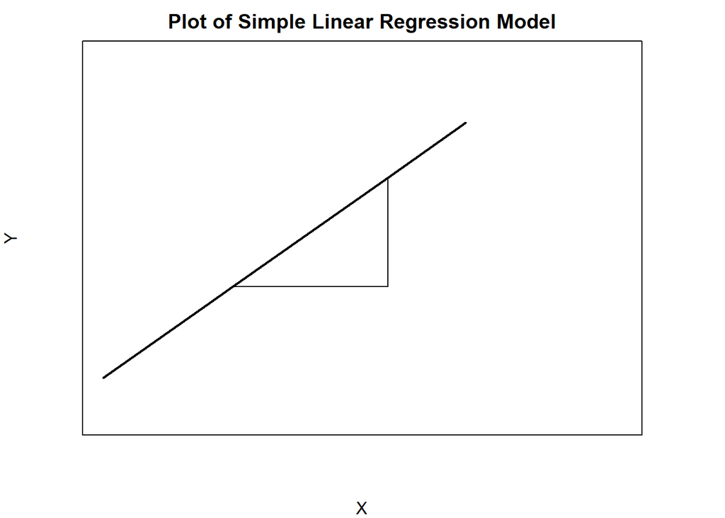

## 1.4 Intercepts and Gradients

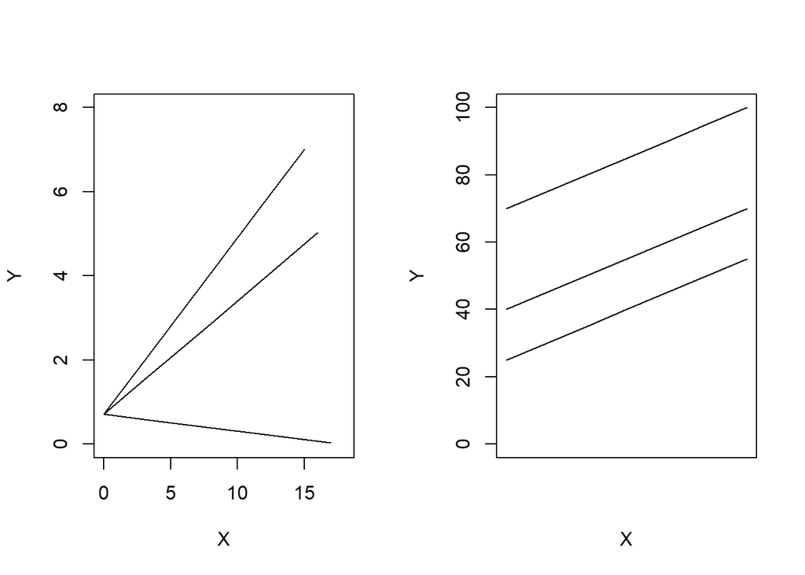

## 1.5 The Method of Least Squares

This is the approach we will use for parameter estimation and inference in this course.

This figure shows a scatterplot of some data with a line representing the best fit model.

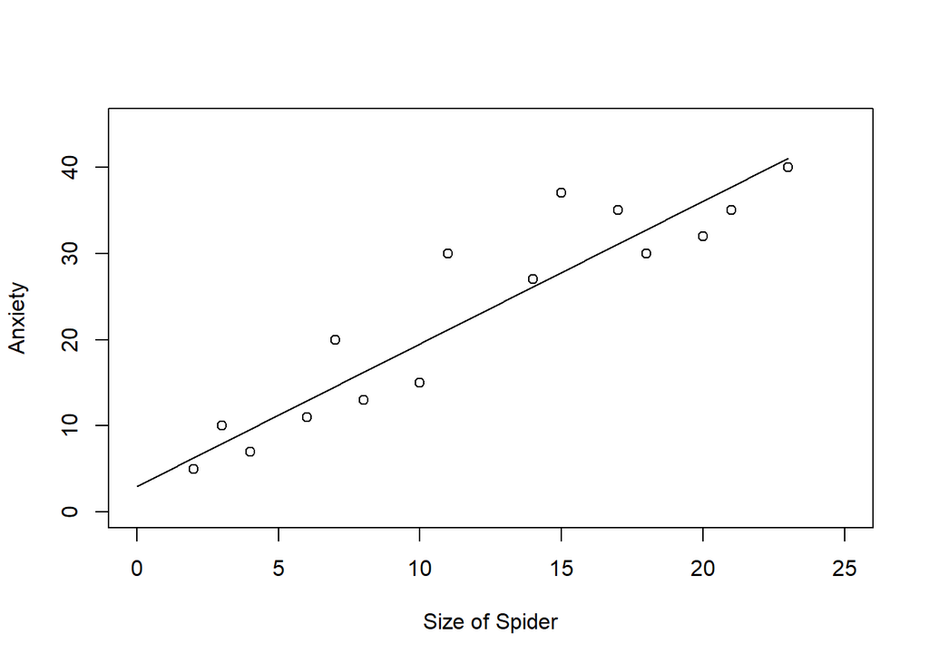

This figure shows the residual (observed - expected) value of the best fit model.

Our task is to minimize the $SS$ value.

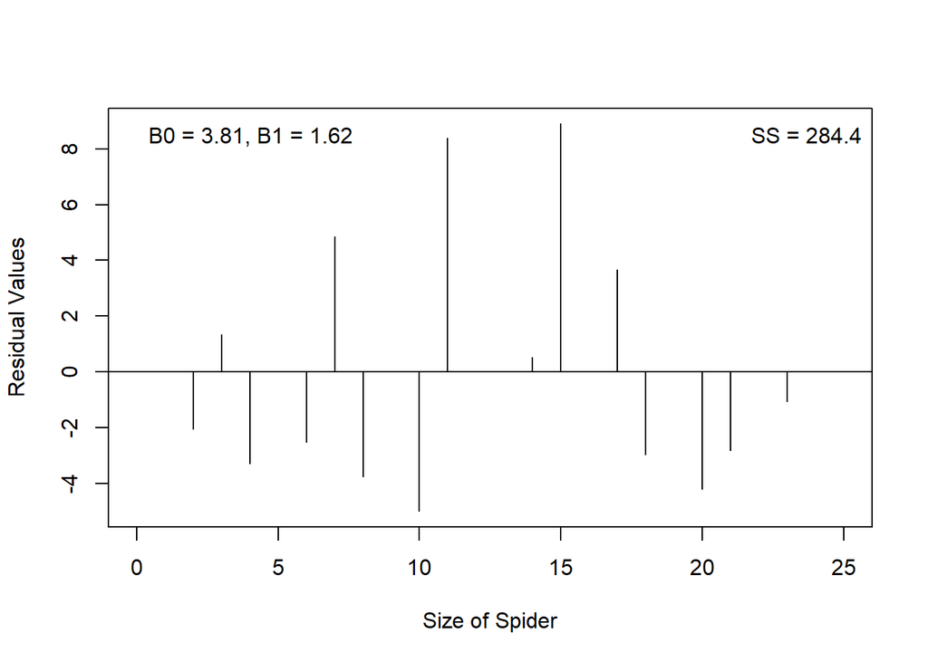

Let’s look at a some cases for alternatvie candidate model parameters:

Our task is to minimize the $SS$ value.

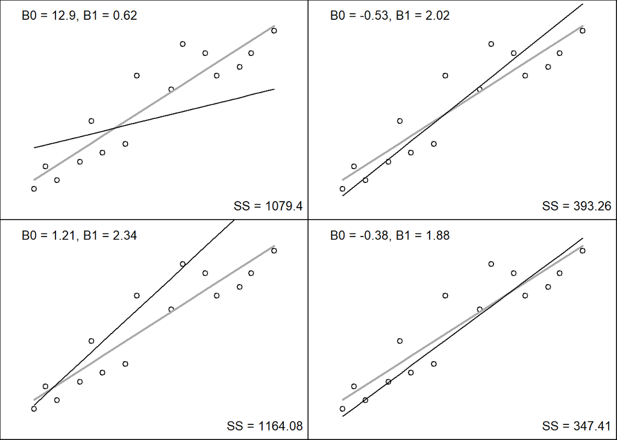

## 1.6 Sum of Squares Components

Once the best fit model is derived, we can make inference about the quality of the model (relative to the null model) and the hypothesis $\beta_1 = 0$.

Let’s take a close look at the three sum of squares components.

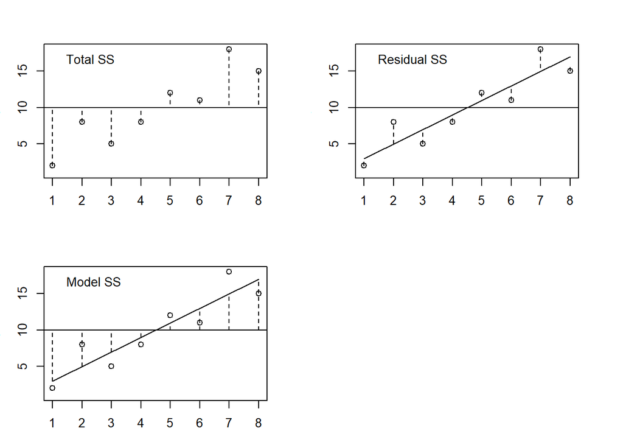

## 1.7 Total SS (SS<sub>T</sub>, SST)

Total variability (variability between scores and the mean) in the observations.

- TSS is the sum of the squared residuals when the most basic model is applied to the data.
- How good is the mean as a model to the observed data?
- Lets consider the mean of *Y* to be the null model:
- SS<sub>T</sub> uses the differences between the observed data and the mean value of *Y* (the null model)
- $TSS =\sum(Y_i - \bar{Y})^2$

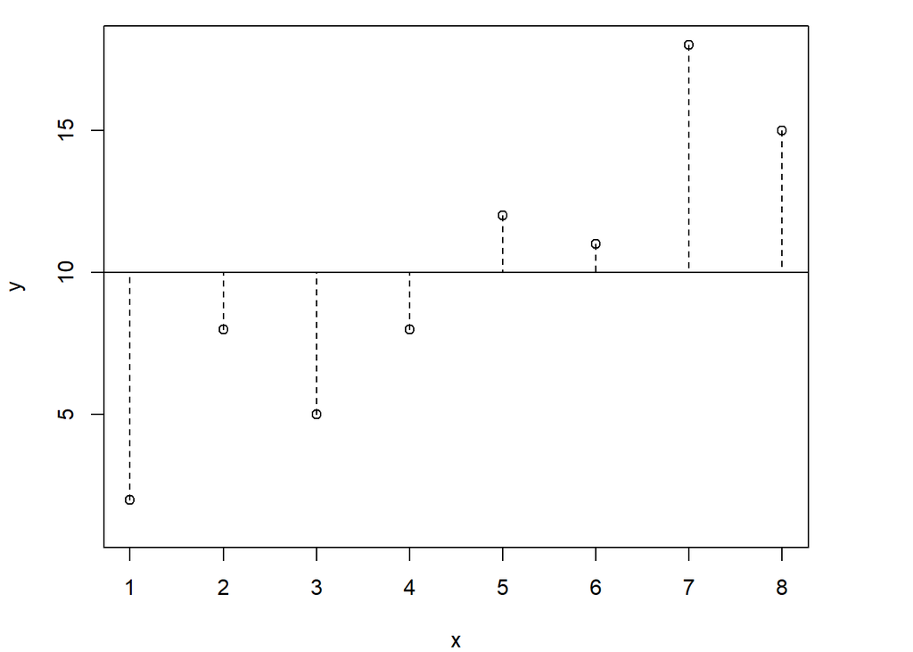

## 1.8 Residual SS or Error SS (SS<sub>R</sub>)

SS<sub>R</sub> is the error that is derived between the regression model and the actual data).

- Difference between the observation and the model
- Represents the degree of inaccuracy when fitting the model to the data.
- Residual/error variability (variability between the regression model and the actual data).
- $RSS =\sum(Y_i - \hat{Y})^2$

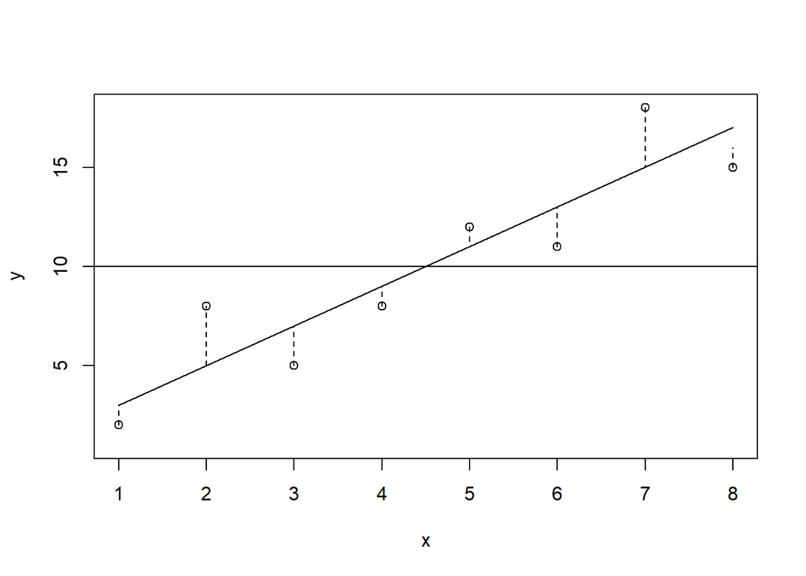

## 1.9 Model SS or Regression SS (SS<sub>M</sub>)

SS<sub>M</sub> is the difference between the prediction from the regression model and the mean (null model).

- This is the improvement we get from fitting the model to the data relative to the null model.
- $SS_M=\sum(\hat{Y}_i - \bar{Y})^2$

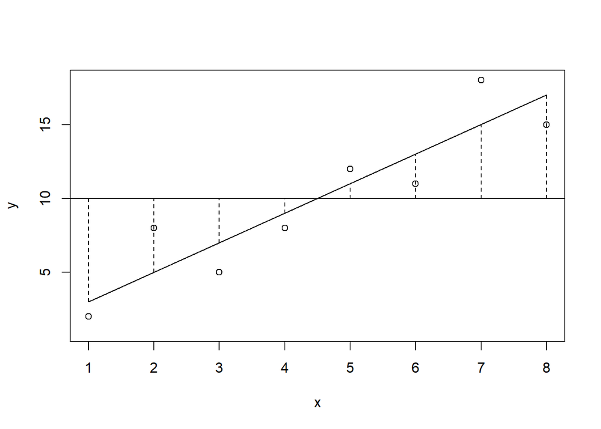

## 1.10 The SS components are related and useful for understanding the model

The total variabilty is partitioned between the model and the residual:

$SS_T = SS_M + SS_R$

We calculate the sum of squares components to evaluate the amount of systematic variance (regression/model) and the amount of unsystematic (residual) variance.

If we have a good model, the total variance in the observations will be described to a great extent by the model.

The proportion of improvement due to the model.

- $R^2 = SS_M/SS_T$, percentage of variation explained by the model.

## 1.11 Variance Ratio Test

We will evalute the model using an *F* test - “termed variance ratio test”.

We will be evaluating the ratio of SSM and SSR.

1. We will use the SSM and SSR to calculate quantities “mean squares”
2. This will be done by dividing the SSM and SSR by their respective degrees of freedom (df). These terms can be expressed as averages, divided by df terms.
- df for SSM (The number of parameters in the model - 1)
- df for SSR (number of obs - number of parameters in the model)

These quantities are called mean squares.

- Mean Squares Model; MS<sub>M</sub> = SS<sub>M</sub>/df<sub>M</sub>
- Mean Squares Residual: MS<sub>R</sub> = SS<sub>R</sub>/df<sub>R</sub>

*F*-test is termed the “variance ratio test”

$F=\frac{MS_M}{MS_R}$

## 1.12 Test $\beta_1 = 0$

To test whether $\beta_1 = 0$ we will use the t-distribution.

After determining the model parameters values we can estimate the standard error of the slope paramter.

The approach is to determine the confidence interval of the slope ($\beta_1$) for a given value of $\alpha$.

Look at the following equation, what values will we need?

$SE_{\beta_1}=\frac {\sqrt{\frac{(\sum{{Y_i - \hat{Y_i}}})^2}{df}}}{\sqrt{\sum{(X_i - \bar{X})^2}}}$

$SE_{\beta_1}=\frac {\sqrt{\frac{(\sum{{Y_i - \hat{Y_i}}})^2}{(n - 2)}}}{\sqrt{\sum{(X_i - \bar{X})^2}}}$

Degrees of freedom: For simple linear regression (one independent and one dependent variable), the degrees of freedom (df) is equal to, n - 2.

Our calculated test statistic is:

$t = \frac{\beta_1}{SE_{\beta_1}}$

We will compare this to the critical value:

$t_{\alpha, 2-tailed, df}$

## 1.13 Worked Example

| Age (days) (X) | Wing Length (cm) (Y) |
| --- | --- |
| 3.0 | 1.4 |
| 4.0 | 1.5 |
| 5.0 | 2.2 |
| 6.0 | 2.4 |
| 8.0 | 3.1 |
| 9.0 | 3.2 |
| 10.0 | 3.2 |
| 11.0 | 3.9 |
| 12.0 | 4.1 |
| 14.0 | 4.7 |
| 15.0 | 4.5 |
| 16.0 | 5.2 |
| 17.0 | 5.0 |

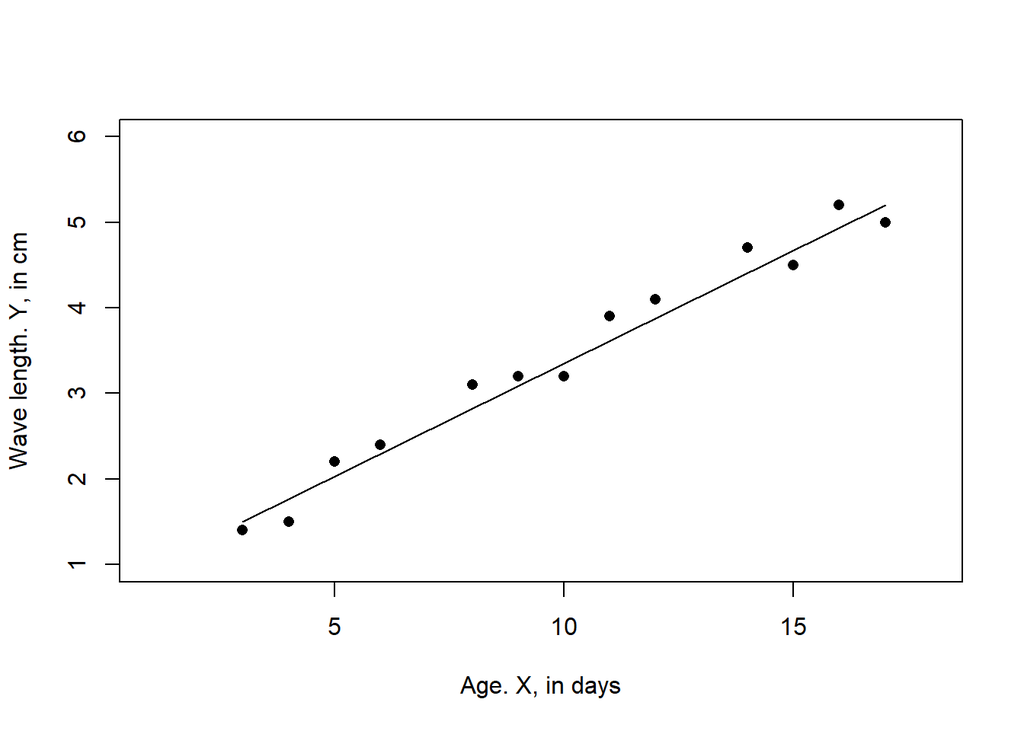

We find that the TSS is = 19.65

We find that the Model SS = 19.13

| Source of Variation | Sum of Squares (SS) | df | Mean Squares (MS) |
| --- | --- | --- | --- |
| Total | $\sum(Y_i-\bar{Y})^2$ |  |  |
| Model (or Regression) | $\sum(\hat{Y}_i-\bar{Y})^2$ | The number of parameters in the model - 1 | SS<sub>M</sub>/df<sub>M</sub> |
| Residual (or Error) | $\sum(Y_i-\hat{Y_i})^2$ | The number of obs - the number of parameters in the model | SS<sub>R</sub>/df<sub>R</sub> |

### 1.13.1 Summary of the Calculations for Model Fit

We are falsifying the null hypothesis: $H_0$: There is no statistically significant relationship between variables x and y.

| Source of Variance | SS | df | MS |
| --- | --- | --- | --- |
| Total | 19.65 | 12 |  |
| Model (or Regression) | 19.13 | 1 | 19.13 |
| Residual (or Error) | 0.52 | 11 | 0.047 |

$F=\frac{19.132214}{0.047701}=401.1$

$F_{0.05(1),1.11} = 4.84$

Therefore, reject H<sub>0</sub>

P < 0.0005

## 1.14 Regression: An Example

A record company executive is interested in predicting record sales from advertising.

Data are:

- 200 different album releases

Outcome variable:

- Sales (CDs and downloads) in the week after release

Predictor variable:

- The amount (in units of $1,000) spent promoting the record before release.

## 1.15 Output of a Simple Regression

In R:

| Coefficients: | Estimate | Std. Error | t value | Pr(> |
| --- | --- | --- | --- | --- |
| (intercept) | 134 | 7.53 | 17.799 | < $2\times10^{-16}$ *** |
| Adverts | 0.096 | 0.00963 | 9.979 | < $2\times10^{-16}$ *** |

- Signif. codes: 0 ‘**’ 0.001 ’**’ 0.01 ’’ 0.05 ‘.’ 0.1 ’ ’ 1
- Residual standard error: 65.99 on 198 degrees of freedom
- Multiple R-squared: 0.3346, Adjusted R-squared: 0.3313
- F-statistic: 99.59 on 1 and 198 df, p-value: < 2.2e-16

## 1.16 Using the Model

Expected Record Sales<sub>i</sub> = 134.14 + (0.096 x Advertising Budget<sub>i</sub>)

E(Record sales if Budget = 100) = 134.14 + (0.096 x 100)

E(Record sales if Budget = 100) = 143.75

## 1.17 Analysis of the slope coeffient

Using the fact that $\beta_1$ is approximately normally distributed in large samples, we can test the hypothesis that $\beta_1 = 0$.

From our reading, we learned that the calculated value of the *t*-statistic is:

$t = \frac{\beta_{observed} - {\beta_{expected}}}{{SE_{\beta}}}$.

For the hypothesis testing, we:

1. Compute the standard error of $\beta_1$, $SE_{\beta_1}$:

$SE_{\beta_1}=\frac {\sqrt{\frac{\sum{{Y_i - \hat{Y_i}}})^2}{{n - 2}}}}{\sqrt{\sum{(X_i - \bar{X})^2}}}$

2. Compute the *t*-statistic, in this case, we are comparing our observed value of $\beta_1$ to the expected value, if the null hypothesis is true. So, our expected value is $\beta_1 = 0$. And we divide this difference by $SE_{\beta_1}$.

$t = \frac{\hat{\beta_1} - 0}{SE_{\beta_1}}$.

$t = \frac{\hat{\beta_1}}{SE_{\beta_1}}$.

This is our computed *t* value.

3. We calculate the critical value of *t*, which is derived using the degrees of freedom. For simple linear regression (one independent and one dependent variable), the degrees of freedom (df) is equal to, n - 2.
4. To determine the 95% CI of $\beta_1$, we can rearrange the above equation:

$t = \frac{\hat{\beta_1} - 0}{SE_{\beta_1}}$.

$t SE_{\beta_1} = \hat{\beta_1}$.

$\hat{\beta_1} = t_{\alpha, df} SE_{\beta_1}$.

If $\alpha = 0.05$, then we would get the 95% confidence interval of $\beta_1$.

## 1.18 An R example

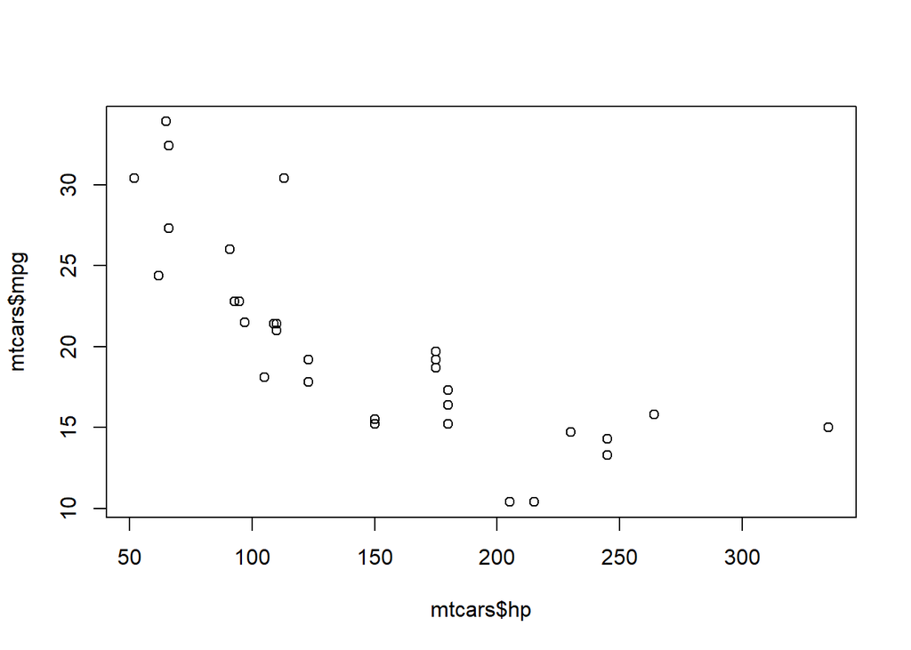

```r
data(mtcars)
plot(mtcars$mpg ~ mtcars$hp)
```

```r
model. <- lm(mtcars$mpg ~ mtcars$hp)

summary(model.)$coef
```

```
##                Estimate Std. Error   t value     Pr(>|t|)
## (Intercept) 30.09886054  1.6339210 18.421246 6.642736e-18
## mtcars$hp   -0.06822828  0.0101193 -6.742389 1.787835e-07
```

The second column of the coefficients’ summary, reports $SE_{\beta_1}$ and $SE_{\beta_0}$.

In the third column t value, we find the *t* statistics suitable for tests of the separate hypotheses:

$\beta_o = 0$ and

$\beta_1 = 0$.

Furthermore, the output provides us with *p*-values corresponding to both tests against the two-sided hypothesis in the fourth column of the table.

Given these results:

$\beta_1 = -0.06822828$

$SE_{\beta_1} = 0.0101193$

$t = \frac{\hat{\beta_1} - 0}{SE_{\beta_1}}$

$t = \frac{ -0.068}{0.0101}$.

$t = -6.742$.

95% CI of $\beta_1$:

$t_{\alpha=0.05, df = (n - k -1)}$

$t_{\alpha=0.05, df = (32 - 2 -1)}$

$t_{\alpha=0.05, df = (29)}$

$t_{\alpha=0.05, df = (29)} = -1.699$

95% CI of $\beta_1$ = $t_{\alpha=0.05, df = 29}SE_{\beta_1}$ }

$\beta_1 = -0.068 \pm 0.017$

## 1.19 Prediction and confidence intervals

Sometimes (often) we will want to use the model to predict values.

For example, suppose we fit a simple linear regression model using hours studied as a predictor variable and exam score as the response variable. Using this model, we might predict that a student who studies for 6 hours will receive an exam score of 91.

However, because there is uncertainty around this prediction, we might create a prediction interval that says there is a 95% chance that a student who studies for 6 hours will receive an exam score between 85 and 97.

This range of values is known as a 95% *prediction interval* and it’s often more useful to us than just knowing the predicted value. The predicted value $\hat{Y_i}$ is called a point and is useful. We would like to report the variability around this value..

Two type of intervals available:

1.) Confidence interval

A confidence interval captures the uncertainty around the mean predicted values.

2.) Prediction interval

The prediction interval predicts in what range a future individual observation will fall. A prediction interval will always be wider than a confidence interval for the same value.

Confidence interval:

$\hat{y} = s_yt_{(\alpha, df = n-2)}\sqrt{\frac{1}{n}+\frac{(X^*-\bar{X})^2}{(n-1)s^2_X}}$

Here, $s_y= \sqrt{\frac{\sum(y_i-\hat{y_i})^2}{n-2}}$

$s_y$ is called residual standard error in R regression output.

Prediction intervals are similar in their calculation

$\hat{y} = s_yt_{(\alpha, df = n-2)}\sqrt{1+\frac{1}{n}+\frac{(X^*-\bar{X})^2}{(n-1)s^2_X}}$

Here, $s_y= \sqrt{\frac{\sum(y_i-\hat{y_i})^2}{n-2}}$

The formula is very similar, except the variability is higher since there is an added 1 in the formula.

## 1.20 An R example - Confidence Intervals

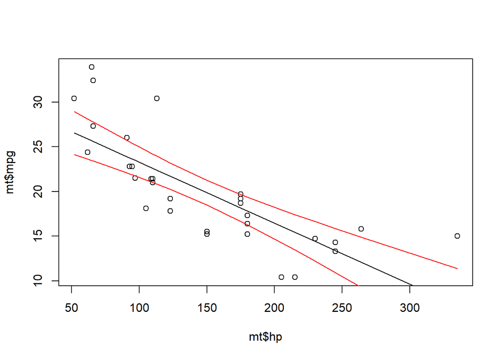

```r
data(mtcars)
mt <- mtcars[order(mtcars$hp),]
plot(mt$mpg ~ mt$hp)
model. <- lm(mt$mpg ~ mt$hp)

new_hp <- data.frame(hp = mt$hp)
pred.vals <- predict(model., newdata = new_hp, interval = "confidence")

lines(cbind(new_hp, pred.vals)[,c(1,2)])
lines(cbind(new_hp, pred.vals)[,c(1,3)], col = "red")
lines(cbind(new_hp, pred.vals)[,c(1,4)], col = "red")
```

## 1.21 An R example - Prediction Intervals

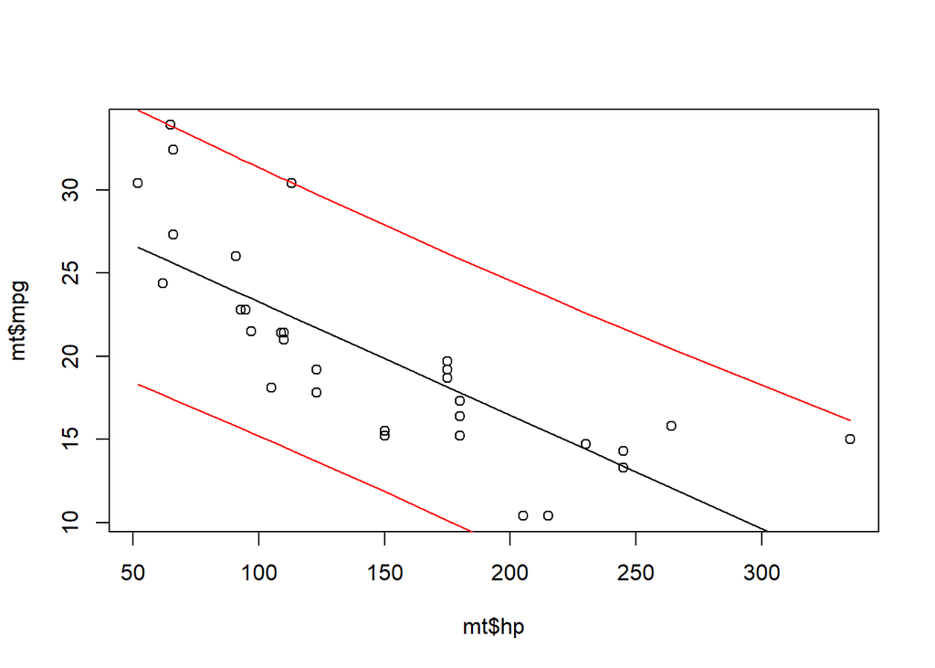

```r
data(mtcars)
mt <- mtcars[order(mtcars$hp),]
plot(mt$mpg ~ mt$hp)
model. <- lm(mt$mpg ~ mt$hp)

new_hp <- data.frame(hp = mt$hp)
pred.vals <- predict(model., newdata = new_hp, interval = "prediction")

lines(cbind(new_hp, pred.vals)[,c(1,2)])
lines(cbind(new_hp, pred.vals)[,c(1,3)], col = "red")
lines(cbind(new_hp, pred.vals)[,c(1,4)], col = "red")
```

# 2 Multiple Linear Regression

Model is fit by minimizing the sum of squared differences between the line and the actual data points - method of least squares.

We still use our base equation:

$outcome=model+error$

But this time the model it is a bit more complicated.

When we add predictors, we add parameters ($\beta$ terms).

So each predictor variable has its own coefficient (parameter) and the outcome is predicted from a combination of all variables multiplied by their respective coefficients ($\beta$ terms).

## 2.1 Multiple Predictors

*Y* is the outcome variable, $\beta_1$ is the coefficient of X1,$\beta_n$ is the coefficient of $X_n$.

We seek to find combinations of $\beta$ values (parameters) that minimize the sum of squares error:

$outcome_i=model_i+error_i$

$error_i = outcome_i - model_i$

As you know, we quantify the error the model fitting using $SS$.

$Y_i=(b_0 + b_1X_{1i}+b_2X_{2i}+\ldots+b_nX_{ni})+\varepsilon_i$

$\varepsilon_i=Y_i-(b_0 + b_1X_{1i}+b_2X_{2i}+\ldots+b_nX_{ni})$

## 2.2 Album Sales Model

From our previous example above of record sales data, we know that advertising accounts for 33% of the variation in album sales.

Remember:

$R^2=\frac{SS_M}{SS_T}$

Therefore a large proportion of variation remains unexplained.

Lets bring a new predictor variable into the mix to see if we can increase the amount of residual variation described by the model: How many times the song was played on the radio during the week prior to its release.

## 2.3 Multiple Predictors Model

We will incorporate a new “airplay” variable.

$E(Album \:Sales_i)=\beta_0+\beta_1X_{advertising \: budget_i}+\beta_2X_{airplay_i}$

## 2.4 Regression “Plane”

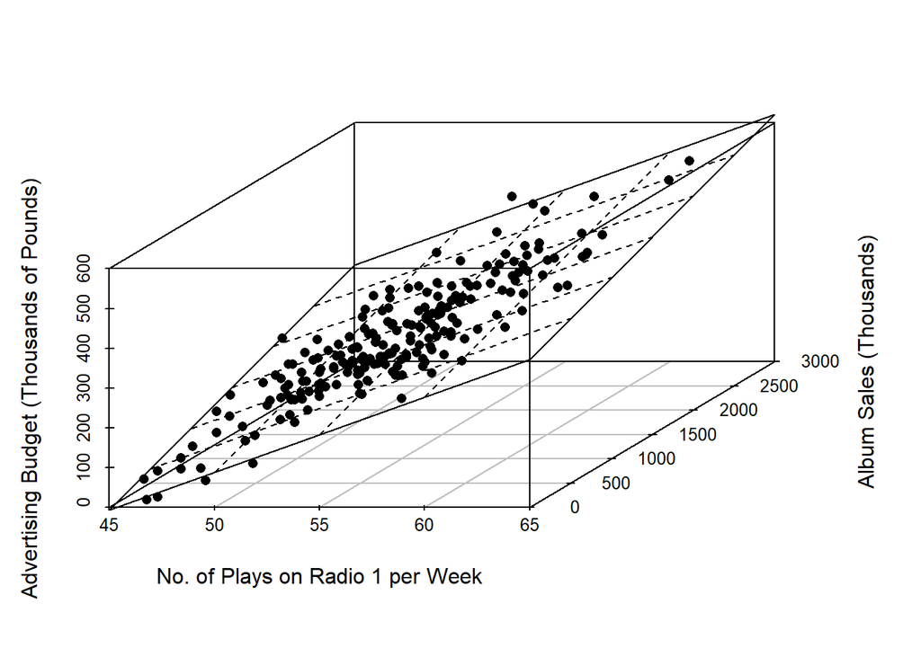

## 2.5 Multiple Linear Regression

| Cities | Y | X<sub>1</sub> | X<sub>2</sub> | X<sub>3</sub> | X<sub>4</sub> | X<sub>5</sub> | X<sub>6</sub> |
| --- | --- | --- | --- | --- | --- | --- | --- |
| Pheonix | 10 | 70.3 | 213 | 582 | 6.0 | 7.05 | 36 |
| Little Rock | 13 | 61.0 | 91 | 132 | 8.2 | 48.52 | 100 |
| San Francisco | 12 | 56.7 | 453 | 716 | 8.7 | 20.66 | 67 |
| Denver | 17 | 51.9 | 454 | 515 | 9.0 | 12.95 | 86 |
| Hartford | 56 | 49.1 | 412 | 158 | 9.0 | 43.37 | 127 |
| Wilmington | 36 | 54.0 | 80 | 80 | 9.0 | 40.25 | 114 |
| Washington | 29 | 57.3 | 434 | 757 | 9.3 | 38.89 | 111 |
| Jacksonville | 14 | 68.4 | 136 | 529 | 8.8 | 54.57 | 116 |
| Miami | 10 | 75.5 | 207 | 335 | 9.0 | 59.80 | 128 |
| Atlanta | 24 | 61.5 | 368 | 497 | 9.1 | 48.34 | 115 |
| Chicago | 110 | 50.6 | 3344 | 3369 | 10.4 | 34.44 | 122 |
| Indianapolis | 28 | 52.3 | 361 | 746 | 9.7 | 38.74 | 121 |
| Des Moines | 17 | 49.0 | 104 | 201 | 11.2 | 30.85 | 103 |
| Wichita | 8 | 56.6 | 125 | 277 | 12.7 | 30.58 | 82 |
| Louisville | 30 | 55.6 | 291 | 593 | 8.3 | 43.11 | 123 |
| New Orleans | 9 | 68.3 | 204 | 361 | 8.4 | 56.77 | 113 |
| Baltimore | 47 | 55.0 | 625 | 905 | 9.6 | 41.31 | 111 |
| Detroit | 35 | 49.9 | 1064 | 1513 | 10.1 | 30.96 | 129 |
| Minneapolis- St. Paul | 29 | 43.5 | 699 | 744 | 10.6 | 25.94 | 137 |
| Kansas City | 14 | 54.5 | 381 | 507 | 10.0 | 37.00 | 99 |
| St. Louis | 56 | 55.9 | 775 | 622 | 9.5 | 35.89 | 105 |
| Omaha | 14 | 51.5 | 181 | 347 | 10.9 | 30.18 | 98 |
| Alburquerque | 11 | 56.8 | 46 | 244 | 8.9 | 7.77 | 58 |
| Albany | 46 | 47.6 | 44 | 116 | 8.8 | 33.36 | 135 |
| Buffalo | 11 | 47.1 | 391 | 463 | 12.4 | 36.11 | 166 |
| Cincinnati | 23 | 54.0 | 462 | 453 | 7.1 | 39.04 | 132 |

*Table of air pollution in 41 U.S. cities associatied with six environmental variables*

## 2.6 Model Interpretation

We regress SO<sub>2</sub> content in the air on average temperature X<sub>1</sub> and the number of manufacturing enterprises, X<sub>2</sub>

A one unit change in $X_2$ results in a 0.02431 increase in *Y*.

## 2.7 Test of Null Hypothesis

We can analyze the null hypothesis that all of the regression coefficients are equal to zero using an ANOVA analysis. This approach is analogous to that used in simple linear regression.

## 2.8 Significance Testing

In general, a significant *F* value will be associated with the rejection of the null hypothesis for some regression coefficients.

## 2.9 Multicollinearity

Sometimes it is possible to have a significant *F* without significant regression coefficients. Multicollinearity occurs when there is multicollinearity among variables.

- This happens when two variables are highly correlated.
- Result in untrustworthy coefficients - serves to increase the variance of the estimate of the $\beta$ values.
- Example: inclusion of one predictor results in R2 = 0.80.
- When you add a highly correlated variable, the variance it accounts for is already described by the first variable - it does not account for unique variance.
- So we only get a slight increase in our *R* value.
- We can deal with this by evaluating the variables prior to inclusion into the model.

## 2.10 Determination of Predictors to Include?

One of the most widespread ways is to use “stepwise” methods, you specify a direction either forward or backward.

Forward selection:

- Initial model with only the constant b0 is made
- Add single predictor that best predicts the outcome by selecting the one with the greatest correlation with the outcome
- If fit is improved, then the predictor is retained
- Repeat

Backward selection:

- As above but remove coefficients one at a time.

## 2.11 Model Design Considerations 1

- Predictor variables must be either continuous or categorical.
- Predictors should have non-zero variance.
- Predictors should not be highly correlated (avoid multicollinearity).
- It is desirable to employ a regression that is parsimonious - as few as necessary but as many as needed.

# 3 Comparing Two Means using *t*-tests

A common situation is the comparison of the means of two populations.

An example of a *t*-test is to evaluate the mean blood clotting times between populations that were given two drugs.

- $H_0: \mu_B = \mu_G$, where $\mu$ is the mean blood clotting time (in minutes)

If the samples came from two normally distributed populations and the variances of the populations are equal ,we can use a two sample *t*-test. These conform to the assumptions of parametric statistics.

- Two samples of data are collected and the sample means calculated.
- The calculated means might differ by either a little or a lot.

## 3.1 Small differences in mean samples values

We expect their means to be equal or very close. In this case, it is possible (even likely) for the population means to differ by chance alone (due to sampling error). We wwould expect that large differences in the mean values would occur very infrequently.

$H_0: \mu_B = \mu_G$

Alternatively, we can pose this as the difference in the mean:

$H_0: \mu_B - \mu_G = 0$.

- We are interested in understanding the magnitude of difference between the sample means.
- We use the standard error as a gauge of the variability between sample means.

## 3.2 Large differences in mean samples values

If the difference between the samples we have collected is large, then we can infer one of two things:

1.) There is no effect of the two blood clotting medicine and by chance we calculated two sample means that are atypical of the population from which they came.

2.) The two samples come from different populations (populations with different mean values). In this scenario, the difference between samples represents a genuine difference between the samples (and we falsify the null hypothesis).

So, this is the null model we are testing; did the samples come from the same population or did the samples come from the different populations?

If the observed difference between the sample means is large: The more confident we become that the second explanation is correct (i.e. that the null hypothesis should be rejected).

## 3.3 Example

- Is arachnophobia (fear of spiders) specific to real spiders or is a picture enough?
- 24 arachnophobic individuals

Experimental Manipulation:

- n = 12 randomly chosen participants were exposed to a real spider.
- n = 12 randomly chosen participants were exposed to a picture of the same spider.
- We monitor the anxiety produced.

## 3.4 We will evaluate these data using a linear model

Consider an experiment where ‘Groups’ were exposed to a “Picture of a Spider” and an “Actual Spider”

The response variable is the level of Anxiety (A)

$\hat{A_i}=b_0+b_1G_i$

The independent variable *G* has only two values “Group 1” and “Group 2” ie. The “real” and “picture” groups.

```
##          Group  Anxiety G
## 1      Picture 20.67124 0
## 2      Picture 36.79956 0
## 3      Picture 38.36280 0
## 4      Picture 26.76544 0
## 5      Picture 36.46704 0
## 6      Picture 15.36294 0
## 7      Picture 20.63903 0
## 8      Picture 23.93972 0
## 9      Picture 40.35177 0
## 10     Picture 41.79260 0
## 11     Picture 31.16043 0
## 12     Picture 28.42174 0
## 13 Real Spider 23.68506 1
## 14 Real Spider 59.23398 1
## 15 Real Spider 35.84786 1
## 16 Real Spider 47.14871 1
## 17 Real Spider 44.51467 1
## 18 Real Spider 52.42887 1
## 19 Real Spider 61.94535 1
## 20 Real Spider 52.43209 1
## 21 Real Spider 39.05075 1
## 22 Real Spider 57.72527 1
## 23 Real Spider 48.60876 1
## 24 Real Spider 41.13388 1
```

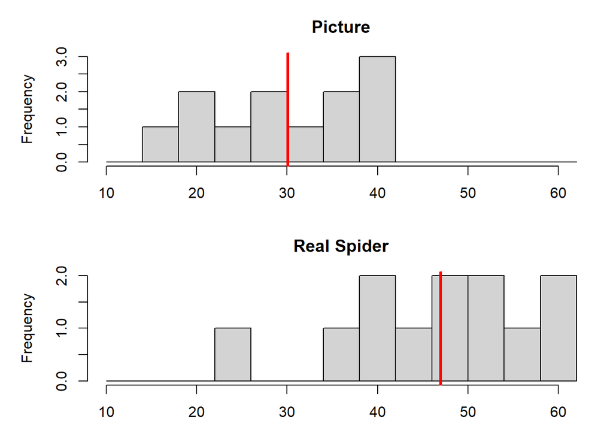

## 3.5 Picture Group

We can code the variable, *G*, as a ‘dummy’ variable. It will take on the values one or zero. We can assign one group to have a value of zero, and one group to have a value of one. In the case of the ‘picture’ group, we will assign a value of *G* to be zero.

$G_{picture}=0$

$\hat{A_i}=b_0+b_1G_i$

The expected anxiety of group “picture” is the mean of anxiety of group “picture”.

$\bar{A}_{Picture}=b_0+b_1G_{picture}$

$\bar{A}_{Picture}=b_0+b_1\times0$

$\bar{A}_{Picture}=b_0$

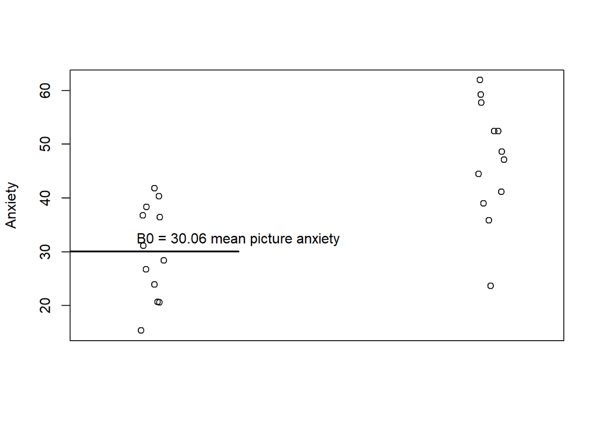

## 3.6 Real Spider Group

Again, we can code the variable, *G*, as a ‘dummy’ variable. It can take on the values one or zero.

We have assigned a value of *G* to be zero for the “picture” group. So, for the “real” group, we will assign the dummy variable *G* to equal one.

$G_{real}=1$

$\hat{A_{G=1}}=b_0+b_1G_i$

$\hat{A_i}=30.06+b_1\times1$

$\hat{A_i}=30.06+b_1$

$b_1 = \hat{A_i}-30.06$

$b_1$ = Difference between means

$b_1=\bar{A}_{Real}-\bar{A}_{Picture}$

Our task is to understand if this $\beta_1$ value is significantly different from zero.

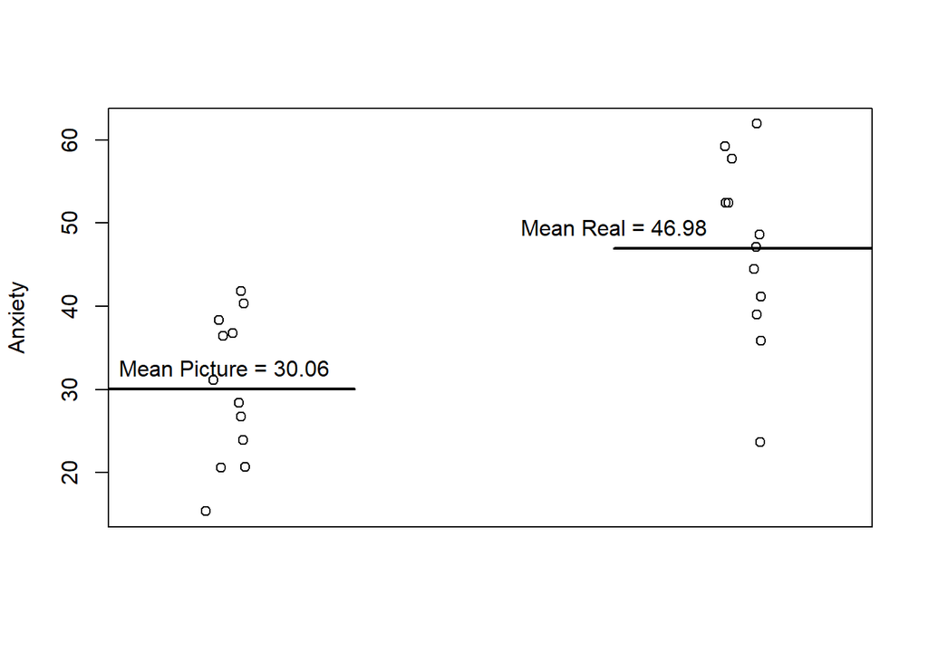

## 3.7 Output from a Regression

Let’s see how this is analyzed in the linear regression approach using R:

```
##
## Call:
## lm(formula = df.$Anxiety ~ df.$Group)
##
## Residuals:
##      Min       1Q   Median       3Q      Max
## -23.2945  -6.5733   0.6342   7.1292  14.9657
##
## Coefficients:
##                      Estimate Std. Error t value Pr(>|t|)
## (Intercept)            30.061      2.864  10.496 4.97e-10 ***
## df.$GroupReal Spider   16.918      4.050   4.177 0.000392 ***
## ---
## Signif. codes:  0 '***' 0.001 '**' 0.01 '*' 0.05 '.' 0.1 ' ' 1
##
## Residual standard error: 9.921 on 22 degrees of freedom
## Multiple R-squared:  0.4423, Adjusted R-squared:  0.4169
## F-statistic: 17.45 on 1 and 22 DF,  p-value: 0.0003915
```

```
## Analysis of Variance Table
##
## Response: df.$Anxiety
##           Df Sum Sq Mean Sq F value    Pr(>F)
## df.$Group  1 1717.4 1717.40  17.448 0.0003915 ***
## Residuals 22 2165.5   98.43
## ---
## Signif. codes:  0 '***' 0.001 '**' 0.01 '*' 0.05 '.' 0.1 ' ' 1
```

## 3.8 The Independent *t-test*

I am using the variable *Y* for the observations - this is a departure from Zar’s presentation but the mechanics are identical.

$t=\frac{\bar{Y}_1-\bar{Y}_2}{\sqrt{\frac{S^2_p}{n_1}+\frac{S^2_p}{n_2}}}$

- The numerator is the difference between sample means.
- The denominator is the standard error of the difference between the sample means. This quantity is a measure of the variability of the data within the two samples.

$S^2_p=\frac{(n_1-1)S^2_1+(n_2-1)S^2_2}{n_1+n_2-2}$

$S^2_p=\frac{SS_1+SS_2}{v_1+v_2}$

Here v<sub>1</sub> and v<sub>2</sub> are the degrees of freedom, v<sub>1</sub> = n<sub>1</sub> - 1 and v<sub>2</sub> = n<sub>2</sub> -1

The test value is compared to the critical value at a given $\alpha$

$t_{\alpha,2,df}$

- Need to set $\alpha$ value.
- One or two-tailed test?
- v<sub>1</sub> = n<sub>1</sub> - 1 and v<sub>2</sub> = n<sub>2</sub> - 1

## 3.9 Lets use the data from Zar as a worked example.

$H_0: \mu_1 = \mu_2$ $H_A: \mu_1\ne\mu_2$

$H_0: \mu_1 - \mu_2 = 0$ $H_A: \mu_1-\mu_2\ne0$

| Given drug B | Given drug G |
| --- | --- |
| 8.8 | 9.9 |
| 8.4 | 9.0 |
| 7.9 | 11.1 |
| 8.7 | 9.6 |
| 9.1 | 8.7 |
| 9.6 | 10.4 |
|  | 9.5 |
| —— |  |
| $n_1=6$ | $n_2=7$ |
| $\nu_1=5$ | $\nu_2=6$ |
| $\bar{Y}_1=$ 8.75 min | $\bar{Y}_2=$ 9.74 min |
| SS<sub>1</sub> = 1.6950 min<sup>2</sup> | SS<sub>2</sub> = 4.0171 min<sup>2</sup> |

$S^2_p=\frac{SS_1+SS_2}{v_1+v_2}=\frac{1.6950+4.0171}{5+6}=\frac{5.7121}{11}=0.5193 \: \mbox{min}^2$

$s_{\bar{Y_1}-\bar{Y}_2}=\sqrt{\frac{S^2_p}{n_1}+\frac{S^2_p}{n_2}}=\sqrt{\frac{0.5193}{6}+\frac{0.5193}{7}}=\sqrt{0.0866+0.0742}$

$=\sqrt{0.1608}=0.40\mbox{min}$

$t=\frac{\bar{Y}_1-\bar{Y}_2}{s_{\bar{Y}_1-\bar{Y}_2}}$

## 3.10 Determine test value

$t=\frac{\bar{Y}_1-\bar{Y}_2}{s_{\bar{Y}_1-\bar{Y}_2}}=\frac{8.75-9.74}{0.40}=\frac{-0.99}{0.40}=-2.475$

$|t|=|\frac{\bar{Y}_1-\bar{Y}_2}{s_{\bar{Y}_1-\bar{Y}_2}}|=2.475$

## 3.11 Determine critical value

$t_{0.05(2),v}=t_{0.05(2),11}=2.201$

Therefore, reject H<sub>0</sub>

$P(|t|\ge2.475)<0.05$ $\: \:$ $P=0.031$

## 3.12 When Assumptions are Broken

- Non-parameteric *t*-test Mann-Whitney “U” Test

+Do not require estimation of $\mu$ and $\sigma$.

+No assumptions about distributions.

- Convert data to RANKS of data.
- Two sample rank test
- Rank from highest to lowest, the greatest value in either group is given a one, second given a two..

$U=n_1n_2+\frac{n_1(n_1+1)}{2}-R_1$

- n<sub>1</sub> and n<sub>2</sub> are the number of observation sin samples 1 and 2.
- R<sub>1</sub> is the sum of the ranks in sample 1

H<sub>0</sub>: Male and female students are the same height. H<sub>A</sub>: Male and female students are not the same height.

$\alpha=0.05$

| Height of males | Height of females | Ranks of male heights | Ranks of female heights |
| --- | --- | --- | --- |
| 193 cm | 178 cm | 1 | 6 |
| 188 | 173 | 2 | 8 |
| 185 | 168 | 3 | 10 |
| 183 | 165 | 4 | 11 |
| 180 | 163 | 5 | 12 |
| 175 |  | 7 |  |
| 170 |  | 9 |  |
| — |  |  |  |
| $n_1=7$ | $n_2=5$ | $R_1=31$ | $R_2=47$ |

$U=n_1n_2+\frac{n_1(n_1+1)}{2}-R_1$

$(7)(5)+\frac{(7)(8)}{2}-31$

$35+28-31$

$32$

$U^1=n_1n_2-U$

$(7)(5)-32$

$U_{0.05(2),5,7}=30$

Because 32>30, H<sub>0</sub> is rejected.

Therefore, we conclude that height is different for male and female students.

# 4 Analysis of Variance (ANOVA)

In this module we will understand the basic principles of ANOVA. We will be analyzing one-way ANOVA, also called ‘one-factor’ ANOVA or ‘single factor Analysis of Variance’. We will be analyzing the impact to the mean value among *k* groups, where $k >2$. ANOVA is a parametric test.

We will stick with Zar’s terminology (p 178, 4th edition).

## 4.1 When and why to use ANOVA

When we want to compare means we can use a *t*-test but this test has limitations, we can only test the equality of two mean values. Often we would like to compare means from three or more groups.

The ANOVA is an extension of regression (and hence is a general linear model).

### 4.1.1 Why Not Use Lots of *t*-tests?

- Inflates the Type I error rate
- $1 - (1- \alpha)^n$

## 4.2 What Does ANOVA Tell Us?

Null hypothesis:

- Like a *t*-test, *one way* ANOVA tests the null hypothesis that the means are the same among groups.

ANOVA is an *omnibus* test:

- It test for an overall test for evaluating the equality of means among groups.
- It tells us that the group means are different.
- It doesn’t tell us which mean(s) differ.

## 4.3 ANOVA as Regression

Let us assume that we test three different medicine levels and want to see if it impacts (results in contrast, i.e. significant differences) the illness level in pigs.

We are going to test the effect of the three groups (*k* = 3), in this case medicine type. The three groups are ‘placebo’, ‘high’, and ‘low’.

The analysis is termed a one-factor test or one-way ANOVA (only a single thing, the medicine, is different).

Pigs are assigned, at random, to each of the three groups. These are the replicates of each group.

$\mbox{illness}_i=b_0+b_1\mbox{low}_i+b_2\mbox{high}_i+\varepsilon_i$

Here $high$ and $low$ are dummy variables, just like *G* in the *t*-test.

| Group | Dummy variable 1 (High) | Dummy variable 2 (Low) |
| --- | --- | --- |
| Placebo | 0 | 0 |
| Low dose medicine | 0 | 1 |
| High dose medicine | 1 | 0 |

## 4.4 Placebo Group

$\mbox{illness}_i=b_0+b_1\mbox{low}_i+b_2\mbox{high}_i+\varepsilon_i$

$\mbox{illness}_i=b_0+(b_1\times 0)+(b_2\times 0)$

$\mbox{illness}_i=b_0$

$\bar{Y}_{placebo}=b_0$

## 4.5 Low Dose Group

$\mbox{illness}_i=b_0+b_1\mbox{low}_i+b_2\mbox{high}_i+\varepsilon_i$

$\mbox{illness}_i=b_0+(b_1\times 1)+(b_2\times 0)$

$\mbox{illness}_i=b_0+b_1$

$\bar{Y}_{low}=\bar{Y}_{placebo}+b_1$

$b_1=\bar{Y}_{low}-\bar{Y}_{placebo}$

## 4.6 High Dose Group

$\mbox{illness}_i=b_0+b_1\mbox{low}_i+b_2\mbox{high}_i+\varepsilon_i$

$\mbox{illness}_i=b_0+(b_1\times 0)+(b_2\times 1)$

$\mbox{illness}_i=b_0+b_2$

$\bar{Y}_{high}= \bar{Y}_{placebo}+b_2$

$b_2=\bar{Y}_{high}-\bar{Y}_{placebo}$

## 4.7 Output from Regression

| Coefficients: | Estimate | Std. Error | t value | Pr(> |
| --- | --- | --- | --- | --- |
| (intercept) | 2.2000 | 0.6272 | 3.508 | 0.00432 ** |
| dummy 1 | 2.8000 | 0.8869 | 3.157 | 0.00827 ** |
| dummy 2 | 1.0000 | 0.8869 | 1.127 | 0.28158 |

Signif. Codes: 0 ‘**’ 0.001 ’**’ 0.01 ’’ 0.05’.’ 0.1 ’’ 1

- residual standard error: 1.402 on 12 degrees of freedom.
- Multiple R-squared: 0.4604, Adjusted R-squared: 0.3704
- *F*-statistic: 5.119 on 2 and 12 df, p-value: 0.02469

## 4.8 Theory of ANOVA

We use SS components:

First, we calculate how much variability there is between scores

- Total sum of squares (SS<sub>T</sub>).

We then calculate how much of this variability can be explained by the model we fit to the data

- How much variability is due to the experimental manipulation? This is evaluated using the model sum of squares (SS<sub>M</sub>)
- How much variability is due to individual differences in performance, residual sum of squares (SS<sub>R</sub>).
- We compare the amount of variability explained by the model (experiment), to the error in the model (individual differences)
- This ratio is called the *F*-ratio.

If the model explains a lot more variability than it can’t explain, then the experimental manipulation has had a significant effect on the outcome.

## 4.9 ANOVA Worked Example

Testing the effects of medicine on illness using three groups:

- Placebo (sugar pill)
- Low dose medicine
- High dose medicine

The outcome/dependent variable (DV) was an objective measure of illness.

## 4.10 The Data

|  | Placebo | Low Dose | High Dose |
| --- | --- | --- | --- |
|  | 3 | 5 | 7 |
|  | 2 | 2 | 4 |
|  | 1 | 4 | 5 |
|  | 1 | 2 | 3 |
|  | 4 | 3 | 6 |
| $\bar{Y}$ | 2.20 | 3.20 | 5.00 |
| *s* | 1.30 | 1.30 | 1.58 |
| *s*<sup>2</sup> | 1.70 | 1.70 | 2.50 |

Grand Mean = 3.467, Grand *s* = 1.767, Grand *s*<sup>2</sup> = 3.124

## 4.11 Step 1: Calculate SS<sub>T</sub>

*SS<sub>T</sub> uses the differences between the observed data and the mean value of Y. Where the mean is the grand mean*

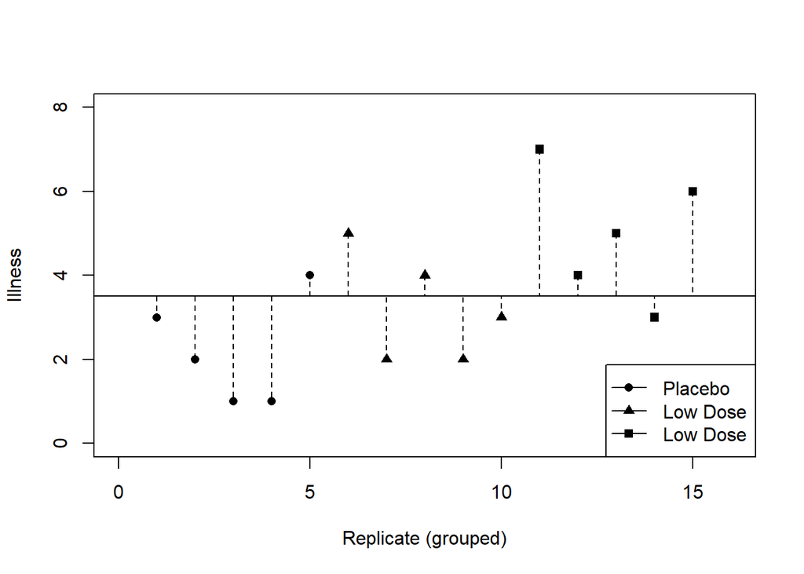

|  | Placebo | Low Dose | High Dose |
| --- | --- | --- | --- |
|  | 3 | 5 | 7 |
|  | 2 | 2 | 4 |
|  | 1 | 4 | 5 |
|  | 1 | 2 | 3 |
|  | 4 | 3 | 6 |
| $\bar{Y}$ | 2.20 | 3.20 | 5.00 |
| *s* | 1.30 | 1.30 | 1.58 |
| *s*<sup>2</sup> | 1.70 | 1.70 | 2.50 |

Grand Mean = 3.467, Grand *s* = 1.767, Grand *s*<sup>2</sup> = 3.124

SS<sub>T</sub> = sum((observed - Grand mean)<sup>2</sup>) $SS_T=\sum(obs_i - \bar{X}_{grand})$

## 4.12 Degrees of Freedom

Degrees of freedom (df) are the number of values that are free to vary.

In general, the df are one less than the number of values used to calculate the SS.

df<sub>Total</sub> = N - 1

## 4.13 Model Sum of Squares (SS<sub>M</sub>)

Difference between the model estimate and the mean (or “Grand Mean”)

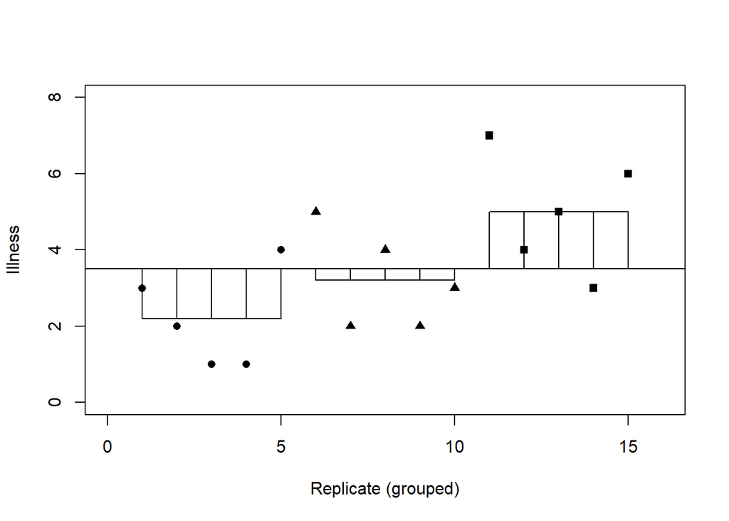

## 4.14 Step 2: Calculate SS<sub>M</sub>

$SS_M=\sum n_i(\bar{x}_i - \bar{x}_{grand})^2$

$SS_M=5(2.2-3.467)^2+5(3.2-3.467)^2+5(5.0-3.467)^2$

$SS_M=5(-1.267)^2+5(-0.267)^2+5(1.533)^2$

$SS_M=8.025+0.355+11.755$

$SS_M=20.135$

## 4.15 Model Degrees of Freedom

How many values did we use to calculate SS<sub>M</sub>?

- We used the 3 means.

$df_M=k-1=3-1=2$

## 4.16 Residual Sum of Squares (SS<sub>R</sub>)

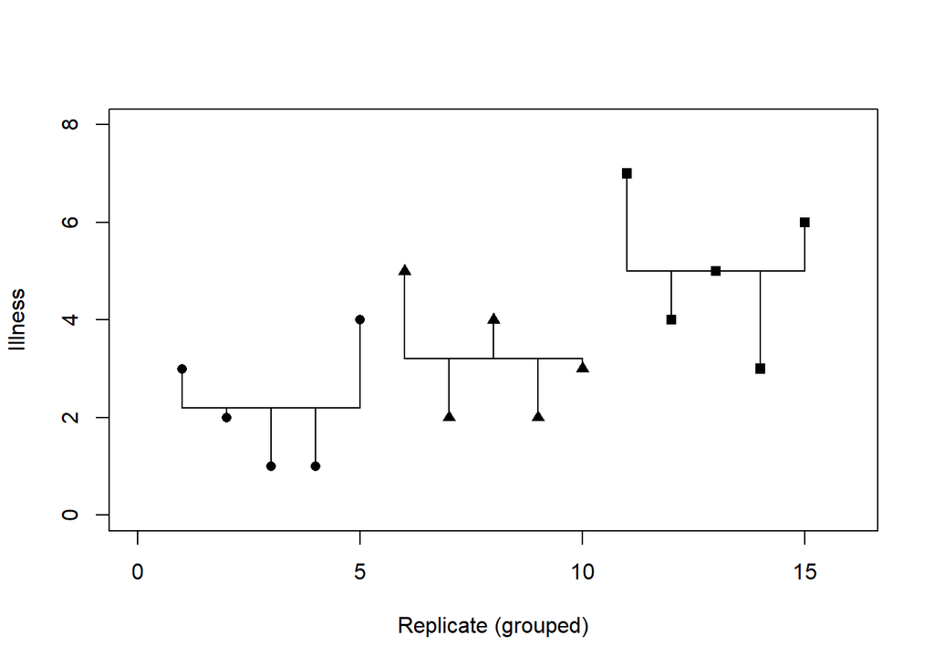

## 4.17 Step 3: Calculate SS<sub>R</sub>

$SS_R=\mbox{sum}([x_i-\bar{x}_i]^2)$

$SS_R=S^2_{group1}(n_1-1)+S^2_{group2}(n_2-1)+S^2_{group3}(n_3-1)$

$SS_R=1.70(5-1)+1.70(5-1)+2.5(5-1)$

$SS_R=(1.70\times4)+(1.70\times4)+(2.50\times4)$

$SS_R=6.8+6.8+10$

$SS_R=23.60$

## 4.18 Residual Degrees of Freedom

- How many values did we use to calculate SS<sub>R</sub>?
- We used the 5 scores for each of the SS for each group.

$df_R=df_{group1}+df_{group2}+df_{group3}$

$df_R=(n_1-1)+(n_2-1)+(n_3-1)$

$df_R=(5-1)+(5-1)+(5-1)$

$df_R=12$

## 4.19 Double Check

$SS_T=SS_R+SS_M$

$43.74=20.14+23.60$

$df_T=df_R+df_M$

$14=2+12$

## 4.20 Step 4: Calculate the Mean Squared Error

$MS_M=\frac{SS_M}{df_M}=\frac{20.135}{2}=10.067$

$MS_R=\frac{SS_R}{df_R}=\frac{23.60}{12}=1.967$

## 4.21 Step 5: Calculate the *F*-Ratio

$F=\frac{MS_M}{MS_R}$

$F=\frac{MS_M}{MS_R}=\frac{10.067}{1.967}=5.12$

## 4.22 Step 6: Construct a Summary Table

| Source | SS | df | MS | F |
| --- | --- | --- | --- | --- |
| Model | 20.14 | 2 | 10.067 | 5.12* |
| Residual | 23.60 | 12 | 1.967 |  |
| Total | 43.74 | 14 |  |  |

## 4.23 Multiple-Comparison Tests

The ANOVA that you examined is used to test the hypothesis that there is no difference in the sample means among *k* treatment levels

However we cannot conclude, after doing the test, which of the mean values are different from one-another.

## 4.24 Tukey Test

Tukey test - balanced, orthogonal designs

Step 1: is to arrange and number all five sample means in order of increasing magnitude

Calculate the pairwise difference in sample means.

We use a *t*-test “analog” to calculate a q-statistic

*S*<sup>2</sup> is the error mean square by ANOVA computation

*n* is the of data in each of groups B and A

Remember this is a completely balanced design.

$SE=\sqrt{\frac{s^2}{n}}$

$q=\frac{\bar{Y}_B-\bar{Y}_A}{SE}$

Start with the largest mean, vs. the smallest mean. Then when the first largest mean has been compared with increasingly large second means, use the second largest mean.

If the null hypothesis is accepted between two means then all other means within that range cannot be different.

# 5 Two-Way Independent ANOVA

Like one-way ANOVA this is a comparison of means test. In this module we will examine multifactor ANOVA.

- Multi-factorial ANOVA as a linear model
- Hypotheses being tested
- Interaction effects
- Post-hoc tests
- Non-parametric versions

## 5.1 What is Two-Way Independent ANOVA?

Two independent variables

- Two-way (*n* = 2) factors

Simultaneous analysis of two factors and measurement of mean response.

Terminology:

One *factor* termed A and one *factor* termed B.

*a* is the number of levels in A.

*b* is the number of levels in B.

## 5.2 Example of two-way ANOVA

Researchers have sought to examine the effects of various types of music on agitation levels in patients in early and middle stages of Alzheimer’s disease.

Patients were selected based on their form of Alzheimer’s disease. Three forms of music were tested: easy listening, Mozart, and piano interludes. The response variable agitation level was scored.

Here is the design:

| Group | Piano Interlude | Mozart | Easy Listening |
| --- | --- | --- | --- |
| Early Stage ALzheimer’s | 21 | 9 | 29 |
|  | 24 | 12 | 26 |
|  | 22 | 10 | 30 |
|  | 18 | 5 | 24 |
|  | 20 | 9 | 26 |
| Middle Stage Alzheimer’s | 22 | 14 | 15 |
|  | 20 | 18 | 18 |
|  | 25 | 11 | 20 |
|  | 18 | 9 | 13 |
|  | 20 | 13 | 19 |

## 5.3 Hypotheses Being Tested

- H<sub>O</sub>: Mean agitation is the same for each music type.
- H<sub>O</sub> : Mean agitation is the same for each Alzheimer’s stage.
- H<sub>O</sub> : Mean agitation is the same for all levels of music, independent of Alzheimer stage.

## 5.4 Multiway Factorial ANOVA Hypotheses Being Tested

| Popcorn | Oil Amt. | Batch | Yeild |
| --- | --- | --- | --- |
| Plain | Little | Large | 8.2 |
| Gourmet | Little | Large | 8.6 |
| Plain | Lots | Large | 10.4 |
| Gourmet | Lots | Large | 9.2 |
| Plain | Little | Small | 9.9 |
| Gourmet | Little | Small | 12.1 |
| Plain | Lots | Small | 10.6 |
| Gourmet | Lots | Small | 18.0 |
| Plain | Little | Large | 8.8 |
| Gourmet | Little | Large | 8.2 |
| Plain | Lots | Large | 8.8 |
| Gourmet | Lots | Large | 9.8 |
| Plain | Little | Small | 10.1 |
| Gourmet | Little | Small | 15.9 |
| Plain | Lots | Small | 7.4 |
| Gourmet | Lots | Small | 16.0 |

## 5.5 Hypotheses Being Tested

Three factor ANOVA:

|  | Df | Sum Sq | Mean Sq | F value | Pr(>F) |
| --- | --- | --- | --- | --- | --- |
| popcorn type | 1 | 3.062 | 3.062 | 0.1731 | 0.6883 |
| oil amount | 1 | 0.062 | 0.062 | 0.0035 | 0.9541 |
| batch size | 1 | 52.562 | 52.562 | 2.9717 | 0.1230 |
| popcorn type:oil amount | 1 | 27.562 | 27.562 | 1.5583 | 0.2472 |
| popcorn type:batch size | 1 | 14.062 | 14.062 | 0.7951 | 0.3986 |
| oil amount:batch size | 1 | 0.063 | 0.063 | 0.0035 | 0.9541 |
| popcorn type:oil amount:batch size | 1 | 1.563 | 1.563 | 0.0883 | 0.7739 |
| Residuals | 8 | 141.500 | 17.687 |  |  |

## 5.6 Benefit of Factorial Designs

1.) The experimental design is an efficient design to test multiple hypotheses simultaneously.

2.) We can look at how variables interact, this process is called ‘interaction’.

- Show how the effects that one level of one group (or factor) might depend on the effects of level in another group.
- Are often more interesting than main effects.

## 5.7 A worked example of factorial design

Testing the effects of the pH of soil and amount of sunlight exposure (full or partial) on mean plant height.

We will test:

## 5.8 Hypotheses Being Tested

- H<sub>O</sub>: Mean plant height is the same in all sunlight treatments.
- H<sub>O</sub> : Mean plant height is the same in all pH treatments.
- H<sub>O</sub> : There is no significant interaction of ph and sunlight.

## 5.9 Remeber the terminology

- Factor A (pH), levels = 6, 7, 8
- Factor B (Sun), levels = full, partial

The response is the height of the plant at the end of the experiment.

The experiment has two “levels” for the factor “B” (b = 2) and three “levels” for the factor “A” (a = 3).

Thus, there are $ab = 3\times2=6$ unique combinations of sun and pH With each combination.

We have *r* = 8 observations for each combination. *r* is called the number of replicates, in each cell.

The total number of replicates (*n*) is:

$N = abr = 3\times2\times8 = 48$.

The amounts $Y_{i,j,k}$ is the amount of plant height for each replicate (*k* = 1 to 8) with sun i, (*i* = 1, 2) at pH *j*, (*j* = 1, 2, 3).

Treatment and level-specific data for the plant height (cm):

| pH (Factor A, *a* levels) | 6 | 6 | 7 | 7 | 8 | 8 |
| --- | --- | --- | --- | --- | --- | --- |
| Sun (Factor B, *b* levels) | Full | Partial | Full | Partial | Full | Partial |
|  | 65 | 50 | 70 | 45 | 55 | 30 |
|  | 70 | 55 | 65 | 60 | 65 | 30 |
|  | 60 | 80 | 60 | 85 | 70 | 30 |
|  | 60 | 65 | 70 | 65 | 55 | 55 |
|  | 60 | 70 | 65 | 70 | 55 | 35 |
|  | 55 | 75 | 60 | 70 | 60 | 20 |
|  | 60 | 75 | 60 | 80 | 50 | 45 |
|  | 55 | 65 | 50 | 60 | 50 | 40 |
| Total | 485 | 535 | 500 | 535 | 460 | 285 |
| Mean | 60.625 | 66.875 | 62.50 | 66.875 | 57.50 | 35.625 |
| Variance | 24.55 | 106.70 | 42.86 | 156.70 | 50.00 | 117.41 |

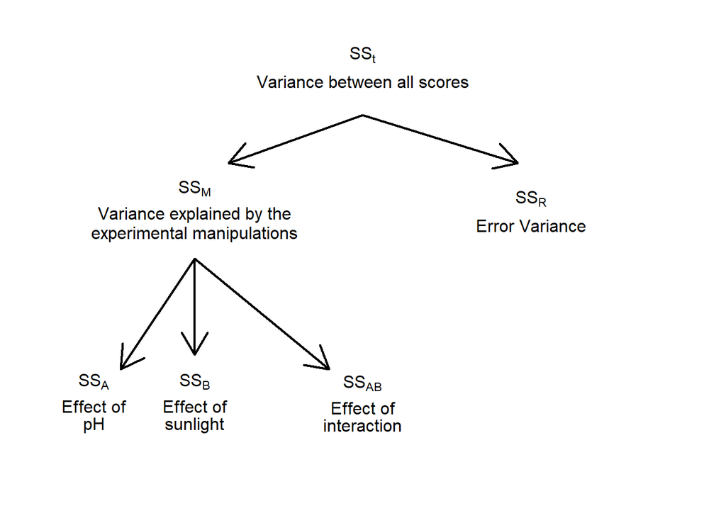

## 5.10 Step 1: Calculate SS<sub>T</sub>

$Grand \: Mean = \bar{X} = 58.33$

$SS_T=\sum_{i=1}^{a}\sum_{j=1}^{b}\sum_{l=1}^{n}({X_{i,j,l} - \bar{X}})^2$

$SS_T=8966.66$

## 5.11 Step 2: Calculate SS<sub>M</sub>

| pH (Factor A, *a* levels) | 6 | 6 | 7 | 7 | 8 | 8 |
| --- | --- | --- | --- | --- | --- | --- |
| Sun (Factor B, *b* levels) | Full | Partial | Full | Partial | Full | Partial |
| Mean | 60.625 | 66.875 | 62.50 | 66.875 | 57.50 | 35.625 |

Here we evaluate main effects and interaction effects.

$SS_M=n\sum_{i=1}^{a}\sum_{j = 1}^{b}({\bar{X}_{ij}}-\bar{X})^2$

$\mbox{SS}_\mbox{M}=8(60.625-58.33)^2+8(66.875-58.33)^2+8(62.5-58.33)^2+8(66.875-58.33)^2+8(57.5-58.33)^2+8(35.625-58.33)^2$

$\mbox{SS}_\mbox{M}=8(2.295)^2+8(8.545)^2+8(4.17)^2+8(8.545)^2+8(-0.83)^2+8(-22.705)^2$

$\mbox{SS}_\mbox{M}=42.1362+584.1362+139.1112+584.1362+5.5112+4124.1362$

$\mbox{SS}_\mbox{M}=5479.17$

Mean “Full Sun”: 60.21 cm

| SS<sub>A</sub> |  |  |
| --- | --- | --- |
| 65 | 70 | 55 |
| 70 | 65 | 65 |
| 60 | 60 | 70 |
| 60 | 70 | 55 |
| 60 | 65 | 55 |
| 55 | 60 | 60 |
| 60 | 60 | 50 |
| 55 | 50 | 50 |

Mean “Partial Sun”: 56.46 cm

| SS<sub>A</sub> |  |  |
| --- | --- | --- |
| 50 | 45 | 30 |
| 55 | 60 | 30 |
| 80 | 85 | 30 |
| 65 | 65 | 55 |
| 70 | 70 | 35 |
| 75 | 70 | 20 |
| 75 | 80 | 45 |
| 65 | 60 | 40 |

$SS_{A} = {rb}\sum_{i=1}^a(\overline{X}_{i} - \overline{X})^2$

$\mbox{SS}_\mbox{Sun}=24(60.21-58.33)^2+24(56.46-58.33)^2$

$\mbox{SS}_\mbox{Sun}=24(1.88)^2+24(-1.87)^2$

$\mbox{SS}_\mbox{Sun}=84.8256+83.9256$

$\mbox{SS}_\mbox{Sun}=168.75$

pH = 6

Mean $\mbox{pH}_6$ = 63.75

| SS<sub>B</sub> |  |
| --- | --- |
| 65 | 50 |
| 70 | 55 |
| 60 | 80 |
| 60 | 65 |
| 60 | 70 |
| 55 | 75 |
| 60 | 75 |
| 55 | 65 |

pH = 7

Mean $\mbox{pH}_7$ = 64.68

| SS<sub>B</sub> |  |
| --- | --- |
| 70 | 45 |
| 65 | 60 |
| 60 | 85 |
| 70 | 65 |
| 65 | 70 |
| 60 | 70 |
| 60 | 80 |
| 50 | 60 |

pH = 8

Mean $\mbox{pH}_8$ = 46.56

| SS<sub>B</sub> |  |
| --- | --- |
| 55 | 30 |
| 65 | 30 |
| 70 | 30 |
| 55 | 55 |
| 55 | 35 |
| 60 | 20 |
| 50 | 45 |
| 50 | 40 |

$SS_B = ra\sum_{j=1}^b(\overline{X}_{j} - \overline{X})^2$

$\mbox{SS}_\mbox{pH}=16(63.75-58.33)^2+16(64.68-58.33)^2+16(46.56-58.33)^2$

$\mbox{SS}_\mbox{pH}=16(5.42)^2+16(6.3575)^2+16(-11.7675)^2$

$\mbox{SS}_\mbox{pH}=470.0224+646.6849+2215.5849$

$\mbox{SS}_\mbox{pH}=3332.292$

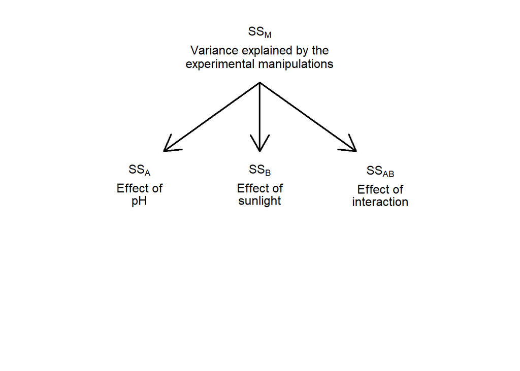

## 5.14 Step 2c: Calculate SS<sub>(AxB)</sub>

$\mbox{SS}_\mbox{M}=\mbox{SS}_{\mbox{A}{\times}\mbox{B}} + \mbox{SS}_\mbox{A}+\mbox{SS}_\mbox{B}$

$\mbox{SS}_{\mbox{A}{\times}\mbox{B}}=\mbox{SS}_\mbox{M}-\mbox{SS}_\mbox{A}-\mbox{SS}_\mbox{B}$

$\mbox{SS}_{\mbox{Sun}{\times}\mbox{pH}}=\mbox{SS}_\mbox{M}-\mbox{SS}_\mbox{Sun}-\mbox{SS}_\mbox{pH}$

$=5479.167-168.75-3332.292$

$=1978.125$

## 5.15 Step 3: Calculate SS<sub>R</sub>

The residual sum of squares is calculated in the same way as for one-way ANOVA .

Represents individual differences in performance or the variance that can’t be explained by factors that were systematically manipulated.

We saw in one-way ANOVA that the value is calculated by taking the squared error between each data point and its corresponding group mean.

So, we use the individual variances of each group and multiply them by one less than the number of people within the group (n).

We have the individual group variances: there were eight people in each group (therefore, *n* = 8).

$\mbox{SS}_\mbox{R}=s^2_{group1}(n_1-1)+s^2_{group2}(n_2-1)+s^2_{group3}(n_3-1)+s^2_{group \: n}(n_n-1)$

$\mbox{SS}_\mbox{R}=s^2_{group1}(n_1-1)+s^2_{group2}(n_2-1)+s^2_{group3}(n_3-1)+s^2_{group4}(n_4-1)+s^2_{group5}(n_5-1)+s^2_{group6}(n_6-1)$

$\mbox{SS}_\mbox{R}=(24.55\times7)+(106.7\times7)+(42.86\times7)+(156.7\times7)+(50\times7)+(117.41\times7)$

$\mbox{SS}_\mbox{R}=171.85+746.9+300+1096.9+350+821.87$

$\mbox{SS}_\mbox{R}=3487.52$

## 5.16 Degrees of Freedom and Mean Square Calculations

| Source | SS | df | MS |
| --- | --- | --- | --- |
| Factor A | $SS_A$ | a-1 | $\frac{SS_A}{a-1}$ |
| Factor B | $SS_B$ | b-1 | $\frac{SS_B}{b-1}$ |
| Factor A x B | $SS_{AB}$ | (a-1)(b-1) | $\frac{SS_{AB}}{(a-1)(b-1)}$ |
| Error | SSE | N-ab | $\frac{SSE}{N-ab}$ |
| Total | SST | N-1 |  |

## 5.17 Interpreting Factorial ANOVA

| Response | Plant Growth |  |  |  |
| --- | --- | --- | --- | --- |
|  | Sum Sq | Df | *F* value | Pr(>*F*) |
| Sunlight | 169 | 1 | 2.0323 | 0.1614 |
| pH | 3332 | 2 | 20.0654 | 7.649e-07 |
| Sunlight:pH | 1978 | 2 | 11.9113 | 7.987e-05 |
| residuals | 3488 | 42 |  |  |

## 5.18 Interpretation: Main Effect pH

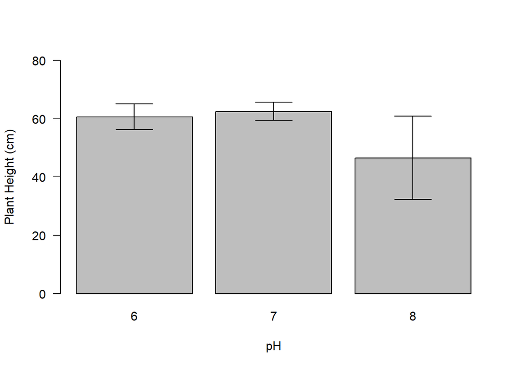

- There was a significant main effect of the amount of pH in the soil on the height of the plant, F(2, 42) = 20.07, p < 0.001

## 5.19 Interpretation: Main Effect Sun

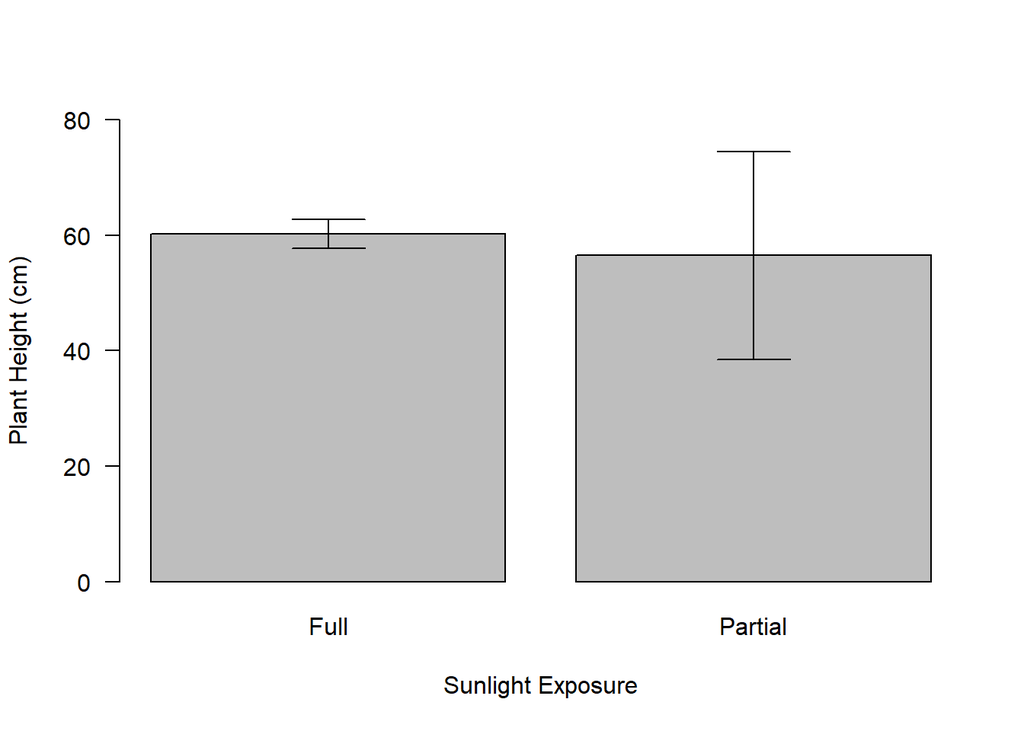

- There was a non-significant main effect of sunlight exposure on the plant height, F(1, 42) = 2.03, p = 0.161.

## 5.20 Interpretation: Interaction Effects

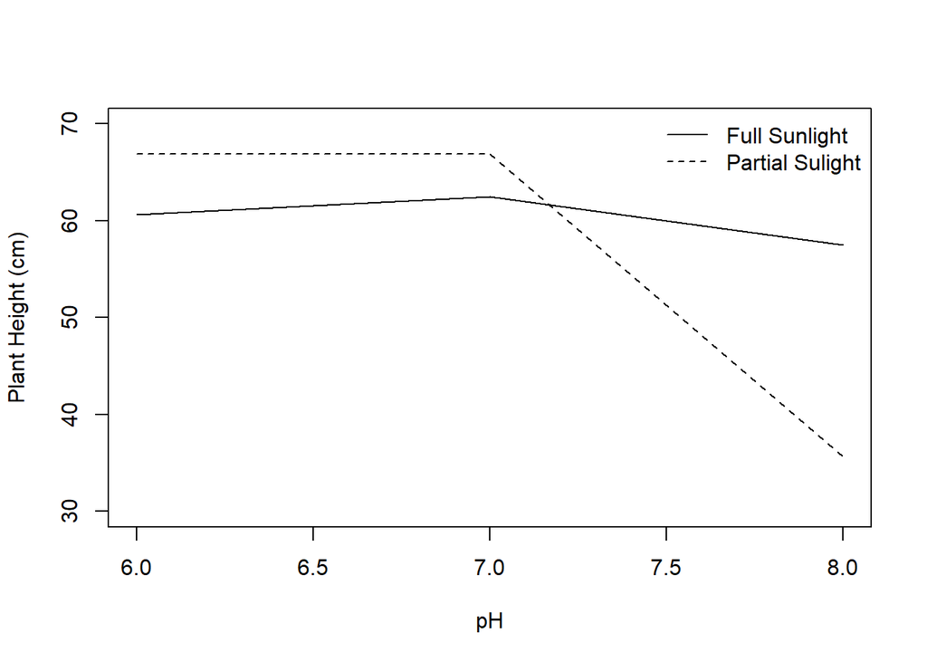

- There was a significant interaction between the amount of pH in the soil and the amount of sunlight exposure, on the height of the plant, F(2, 42) = 11.91, p < .001.
- Non-parallel lines indicate such an interaction: For low pH full and partial sunlight, scores do not change much.
- At a high pH, partial sunlight scores plummet but full sunlight scores remain fairly high. So, the interaction is caused by a difference between sunlight exposure in the height of plants.

## 5.21 Factorial ANOVA as Regression

| pH | 6 | 6 | 7 | 7 | 8 | 8 |
| --- | --- | --- | --- | --- | --- | --- |
| Sunlight | Full | Partial | Full | Partial | Full | Partial |
|  | 65 | 50 | 70 | 45 | 55 | 30 |
|  | 70 | 55 | 65 | 60 | 65 | 30 |
|  | 60 | 80 | 60 | 85 | 70 | 30 |
|  | 60 | 65 | 70 | 65 | 55 | 55 |
|  | 60 | 70 | 65 | 70 | 55 | 35 |
|  | 55 | 75 | 60 | 70 | 60 | 20 |
|  | 60 | 75 | 60 | 80 | 50 | 45 |
|  | 55 | 65 | 50 | 60 | 50 | 40 |
| Total | 485 | 535 | 500 | 535 | 460 | 285 |
| Mean | 60.625 | 66.875 | 62.50 | 66.875 | 57.50 | 35.625 |
| Variance | 24.55 | 106.70 | 42.86 | 156.70 | 50.00 | 117.41 |

$outcome_i = (\mbox{model})+\mbox{error}_i$

$plant height_i=(b_0+b_{1}\mbox{Sunlight}_i+b_2\mbox{pH}_i)+\varepsilon_i$

$plant height_i=(b_0+b_1A_i+b_2B_i+b_3AB_i)+\varepsilon_i$

$plant height_i=(b_0+b_1Sunlight_i+b_2pH_i+b_3interaction_i)+\varepsilon_i$

- How do we code the interaction term?
- Multiply the variables
- *A* x *B*

| Sunlight | pH | Dummy (Sunlight) | Dummy (pH) | Interaction | Mean |
| --- | --- | --- | --- | --- | --- |
| Partial | 6 | 0 | 0 | 0 | 66.875 |
| Partial | 8 | 0 | 1 | 0 | 35.625 |
| Full | 6 | 1 | 0 | 0 | 60.625 |
| Full | 8 | 1 | 1 | 1 | 57.500 |

$plant height_i=(b_0+b_1Sunlight_i+b_2pH_i+b_3interaction_i)+\varepsilon_i$

$\bar{Y}_{partial,6}=b_0+(b_1\times0)+(b_2\times0)+(b_3\times0)$

$b_0=\bar{Y}_{partial,6}$

$b_0=66.875$

| Sunlight | pH | Dummy (Sunlight) | Dummy (pH) | Interaction | Mean |
| --- | --- | --- | --- | --- | --- |
| Partial | 6 | 0 | 0 | 0 | 66.875 |
| Partial | 8 | 0 | 1 | 0 | 35.625 |
| Full | 6 | 1 | 0 | 0 | 60.625 |
| Full | 8 | 1 | 1 | 1 | 57.500 |

$\bar{Y}_{Full,6}=b_0+(b_1\times1)+(b_2\times0)+(b_3\times0)$

$\bar{Y}_{Full,6}=b_0+b_1$

$\bar{Y}_{Full,6}=\bar{Y}_{partial,6}+b_1$

$b_1=\bar{Y}_{Full,6}-\bar{Y}_{partial,6}$

$b_1=60.625-66.875$

$b_1=-6.25$

| Sunlight | pH | Dummy (Sunlight) | Dummy (pH) | Interaction | Mean |
| --- | --- | --- | --- | --- | --- |
| Partial | 6 | 0 | 0 | 0 | 66.875 |
| Partial | 8 | 0 | 1 | 0 | 35.625 |
| Full | 6 | 1 | 0 | 0 | 60.625 |
| Full | 8 | 1 | 1 | 1 | 57.500 |

| Sunlight | pH | Dummy (Sunlight) | Dummy (pH) | Interaction | Mean |
| --- | --- | --- | --- | --- | --- |
| Partial | 6 | 0 | 0 | 0 | 66.875 |
| Partial | 8 | 0 | 1 | 0 | 35.625 |
| Full | 6 | 1 | 0 | 0 | 60.625 |
| Full | 8 | 1 | 1 | 1 | 57.500 |

$b_3=66.875-60.625+57.500-35.625$

$b_3=28.125$

## 5.22 Interaction Effects

Experiment: we are interested in oxygen consumption of two species of limpets in different concentration of seawater.

- Factor A is the species of limpet (levels, a)
- Factor B is the concentration of SW as a function of maximum salinity - 100, 75, and 50 % (levels, b)

| Completed anova |  |  |  |
| --- | --- | --- | --- |
| Source of variation | df | SS | MS |
| Species | 1 | 16.6380 | 16.638 ns |
| salinities | 2 | 10.3566 | 5.178 ns |
| Sp X Sal | 2 | 194.8907 | 97.445 ** |
| Error | 42 | 401.5213 | 9.560 |
| Total | 47 | 623.4066 |  |

When the two factors are identified as A and B, the interaction is identified as the A X B interaction.

Variability not accounted for by A and B alone.

Interaction: The effect of one factor in the presence of a particular level of another factor.

There is an interaction between two factors if the effect of one factor depends on the levels of the second factor.

[output not shown]

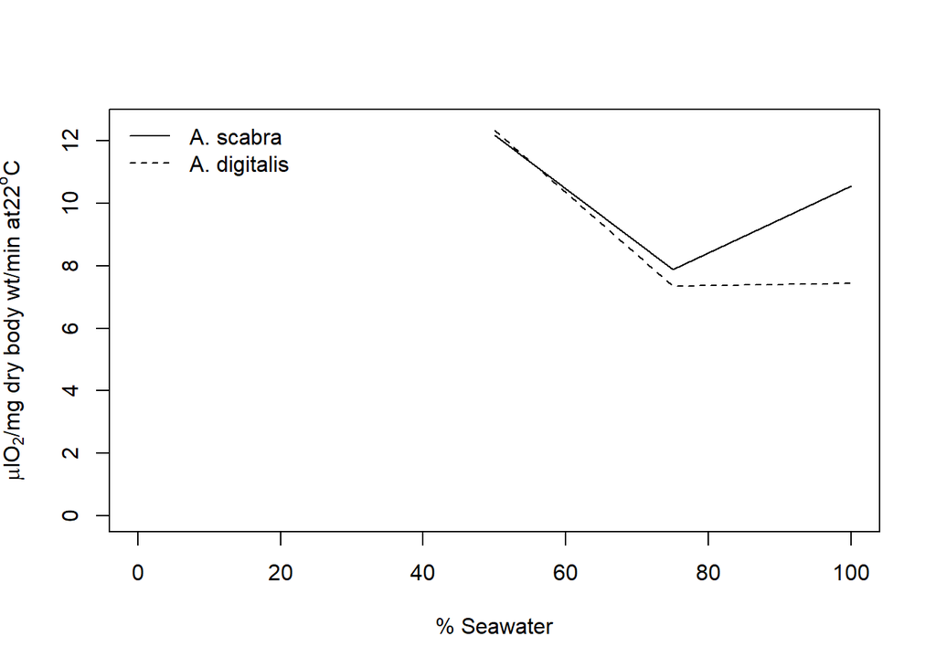

## 5.23 Post-hoc Tests

Tukey test - balanced, orthogonal designs

- Step one: is to arrange and number all five sample means in order of increasing magnitude
- Calculate the pairwise difference in sample means.

We use a *t*-test “analog” to calculate a q-statistic

Scheffe’s test

Examine multiple contrasts:

- ideas is to compare combinations of samples to each other instead of the comparison among individual k levels.

$H_0:\mu_2/3+\mu_4/3+\mu_3/3-\mu_5=0$

$H_0:(\mu_2+\mu_4+\mu_3)/3=\mu_5$

$c_2=\frac{1}{3}, \: c_4=\frac{1}{3}, \: c_3=\frac{1}{3}, \: and \: c_5=-1$

Alternatives multiple contrasts:

$H_0:(\mu_1+\mu_5)/2-(\mu_2+\mu_4+\mu_3)/3=0$

$H_0:\mu_1-(\mu_2+\mu_4+\mu_3)/3$

Test Statistic:

$s=\frac{|\sum c_i\bar{Y}_i|}{SE}$

- Where

$SE=\sqrt{s^2(\sum \frac{c^2_i}{n_i})}$

- and the critical value of the test is

$S_{\alpha}=\sqrt{(k-1)F_{\alpha(1),k-1,N-k}}$

## 5.24 Non-Parametric Tests

Violations of the assumptions

We assume equality of variance - ANOVA is a robust test.

Robust to unbalanced design.

How to deal with outliers:

- use in analysis if they are valid data.

Test of normality: Shapiro Wilks

Test of equality of variance: Bartletts test.

Nonparametric analysis of variance.

If k > 2

Kruskal-Wallis test - analysis of variance by rank

Power increases with sample size.

If k = 2 the Kruskal-Wallis is equivalent to the Mann-Whitney test.

$H=\frac{12}{N(N+1)}\sum ^k_{i=1}\frac{R^2_i}{n_i}-3(N+1)$

If there are tied ranks

- H needs to be corrected using a correction factor C.

$C=1-\frac{\sum t}{N^3-N}$

$H_c=\frac{H}{C}$

$\sum t=\sum (t^3_i-t_i)$

- t<sub>i</sub> is the number of tied ranks.

A limnologist obtained eight containers of water from each of four ponds. The pH of each water sample was measured. The data are arranged in ascending order within each pond. (One of the containers from pond 3 was lost, so n<sub>3</sub> = 7, instead of 8; but the test procedure does not require equal numbers of data in each group.) The rank of each datum is shown parenthetically.

- H<sub>0</sub>: pH is the same in all four ponds.
- H<sub>A</sub>: pH is not the same in all four ponds.

| Pond 1 | Pond 2 | Pond 3 | Pond 4 |
| --- | --- | --- | --- |
| 7.68 (1) | 7.71 (6*) | 7.74 (13.5*) | 7.71 (6*) |
| 7.69 (2) | 7.73 (10) | 7.75 (16) | 7.71 (6*) |
| 7.70 (3.5*) | 7.74 (13.5*) | 7.77 (18) | 7.74 (13.5) |
| 7.70 (3.5*) | 7.74 (13.5*) | 7.78 (20*) | 7.79 (22) |
| 7.72 (8) | 7.78 (20*) | 7.80 (23.5*) | 7.81 (26*) |
| 7.73 (10*) | 7.78 (20*) | 7.81 (26*) | 7.85 (29) |
| 7.73 (10*) | 7.80(23.5*) | 7.84 (28) | 7.87 (30) |
| 7.76 (17) | 7.81 (26*) |  | 7.91 (31) |

| n<sub>1</sub> =8 | n<sub>2</sub> =8 | n<sub>3</sub> =7 | n<sub>4</sub> =8 |
| --- | --- | --- | --- |
| R<sub>1</sub> =55 | R<sub>2</sub> =132.5 | R<sub>3</sub> =145 | R<sub>4</sub> =163.5 |

*tied ranks

$H=\frac{12}{N(N+1)}\sum ^k_{i=1}\frac{R^2_i}{n_i}-3(N+1)$

$=\frac{12}{32(32)}[\frac{55^2}{8}+\frac{132.5^2}{8}+\frac{145^2}{7}+\frac{163.5^2}{8}]-3(32)$

$=11.876$

| Pond 1 | Pond 2 | Pond 3 | Pond 4 |
| --- | --- | --- | --- |
| 7.68 (1) | 7.71 (6*) | 7.74 (13.5*) | 7.71 (6*) |
| 7.69 (2) | 7.73 (10) | 7.75 (16) | 7.71 (6*) |
| 7.70 (3.5*) | 7.74 (13.5*) | 7.77 (18) | 7.74 (13.5) |
| 7.70 (3.5*) | 7.74 (13.5*) | 7.78 (20*) | 7.79 (22) |
| 7.72 (8) | 7.78 (20*) | 7.80 (23.5*) | 7.81 (26*) |
| 7.73 (10*) | 7.78 (20*) | 7.81 (26*) | 7.85 (29) |
| 7.73 (10*) | 7.80(23.5*) | 7.84 (28) | 7.87 (30) |
| 7.76 (17) | 7.81 (26*) |  | 7.91 (31) |

| n<sub>1</sub> =8 | n<sub>2</sub> =8 | n<sub>3</sub> =7 | n<sub>4</sub> =8 |
| --- | --- | --- | --- |
| R<sub>1</sub> =55 | R<sub>2</sub> =132.5 | R<sub>3</sub> =145 | R<sub>4</sub> =163.5 |

*tied ranks

$\sum t=\sum (t^3_i-t_i)$

$\sum t=(2^3-2)+(3^3-3)+(3^3-3)+(4^3-4)+(3^3-3)+(2^3-2)+(3^3-)$

$\sum t=168$

| Pond 1 | Pond 2 | Pond 3 | Pond 4 |
| --- | --- | --- | --- |
| 7.68 (1) | 7.71 (6*) | 7.74 (13.5*) | 7.71 (6*) |
| 7.69 (2) | 7.73 (10) | 7.75 (16) | 7.71 (6*) |
| 7.70 (3.5*) | 7.74 (13.5*) | 7.77 (18) | 7.74 (13.5) |
| 7.70 (3.5*) | 7.74 (13.5*) | 7.78 (20*) | 7.79 (22) |
| 7.72 (8) | 7.78 (20*) | 7.80 (23.5*) | 7.81 (26*) |
| 7.73 (10*) | 7.78 (20*) | 7.81 (26*) | 7.85 (29) |
| 7.73 (10*) | 7.80(23.5*) | 7.84 (28) | 7.87 (30) |
| 7.76 (17) | 7.81 (26*) |  | 7.91 (31) |

| n<sub>1</sub> =8 | n<sub>2</sub> =8 | n<sub>3</sub> =7 | n<sub>4</sub> =8 |
| --- | --- | --- | --- |
| R<sub>1</sub> =55 | R<sub>2</sub> =132.5 | R<sub>3</sub> =145 | R<sub>4</sub> =163.5 |

*tied ranks

$\sum t=\sum (t^3_i-t_i)$

$\sum t=(2^3-2)+(3^3-3)+(3^3-3)+(4^3-4)+(3^3-3)+(2^3-2)+(3^3-)$

$\sum t=168$

$C=1-\frac{\sum t}{N^3-N}=1-\frac{168}{31^3-31}=1-\frac{168}{29760}=0.9944$

$H_c=\frac{H}{C}=\frac{11.876}{0.9944}=11.943$

$\nu=k-1=3$

$F=\frac{(N-k)H_c}{(k-1)(N-1-H_c)}=\frac{(31-4)(11.943)}{(4-1)(31-1-11.943)}=5.95$

$F_{0.05(1),3,26}=2.98$

Reject H<sub>0</sub>

# 6 Logistic Regression

## 6.1 When and why do we use logistic regression?

In some cases the response rariable (or dependent variable, DV) is binomially distributed.

We need an alternative approach because having a categorical outcome variable violates the assumption of linearity in normal regression.

Suppose we want to predict whether someone is diabetic by evaluating plasma glucose . We could plot the relations between the two variables as we customarily do in regression.

Note: It is customary to code a binary DV either 0 or 1.

```
##     1     2
## "neg" "pos"
```

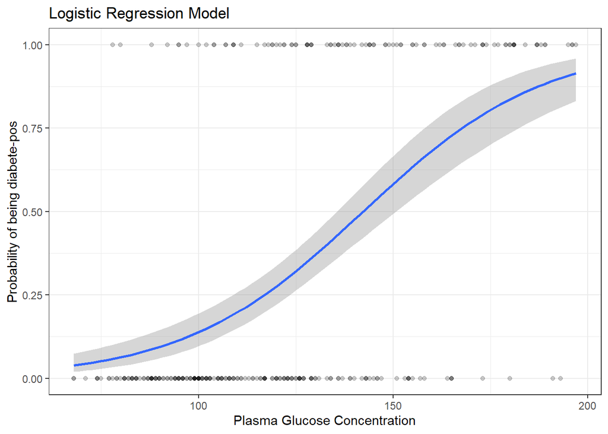

Here we code one DV as 1 and the other as 0 (positive and negative for diabetes).

If we code like this, then the mean of the distribution is equal to the proportion of 1’s in the distribution.

```r
library(tidyverse)
library(caret)
theme_set(theme_bw())


# Load the data and remove NAs
data("PimaIndiansDiabetes2", package = "mlbench")
PimaIndiansDiabetes2 <- na.omit(PimaIndiansDiabetes2)

# Number positive
length(which(PimaIndiansDiabetes2$diabetes == "pos"))
```

```
## [1] 130
```

```r
# Number negative
length(which(PimaIndiansDiabetes2$diabetes == "neg"))
```

```
## [1] 262
```

```r
# Total number
length((PimaIndiansDiabetes2$diabetes))
```

```
## [1] 392
```

For example if there are 100 people in the distribution and 30 of them are coded 1, then the mean of the distribution is 0.30, which is the proportion of 1s.

The mean of the distribution is also the probability of drawing a person labeled as 1 at random from the distribution.

That is, if we grab a person at random from our sample of 100 that I just described, the probability that the person will be a 1 is 0.30.

Therefore, proportion and probability of 1 are the same in such cases. The mean of a binary distribution so coded is denoted as *P*, the proportion of 1s. The proportion of zeros is (1-*P*),which is sometimes denoted as *Q*.

$P = $ numer of ‘ones’

$Q = 1 - P$

The variance of such a distribution is $P \times Q$, and the standard deviation is $\sqrt{PQ}$.

## 6.2 When and Why?

To predict an outcome variable that is categorical from one or more categorical or continuous predictor variables.

In this class we will focus on regression with one predictor.

$P=\frac{1}{1+e^{-(b_0+b_1X_)}}$

## 6.3 What are we predicting?

In the equation above:

- *P* is the probability of a 1 (the proportion of 1s, the mean of Y),
- *e* is the base of the natural logarithm (about 2.718),
- and $b_0$ and $b_1$ are the parameters of the model.

The value of $b_0$ yields *P* when *X* is zero, and $b_1$ adjusts how quickly the probability changes with changing X a single unit.

The relation between *X* and *P* is nonlinear.

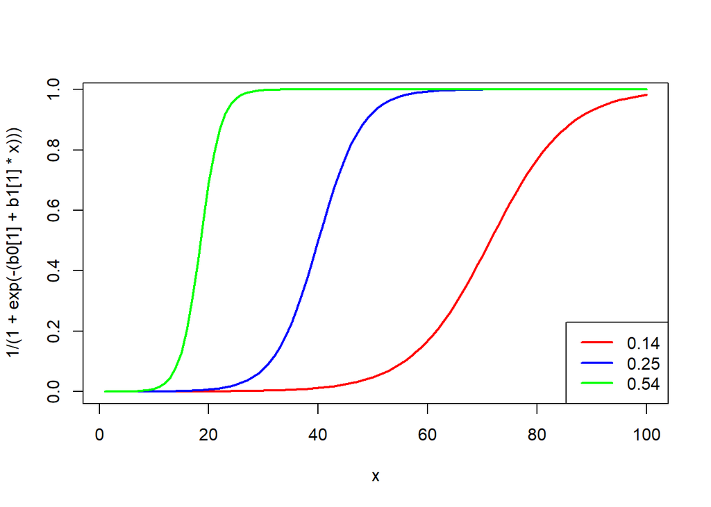

```r
b0 = rep(-10,3)
b1 = c(0.14,0.25,0.54)
x = seq(1,100)
plot(x, 1/(1+exp(-(b0[1] + b1[1]*x))), type = 'n')
lines(x, 1/(1+exp(-(b0[1] + b1[1]*x))), col = "red", lwd = 2)
lines(x, 1/(1+exp(-(b0[1] + b1[2]*x))), col = "blue", lwd = 2)
lines(x, 1/(1+exp(-(b0[1] + b1[3]*x))), col = "green", lwd = 2)
legend('bottomright', legend = b1, col = c('red', 'blue', 'green'), lwd = rep(2, 3))
```

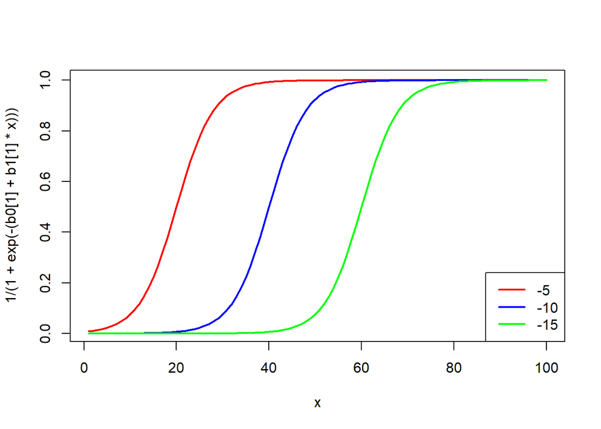

```r
b0 = c(-5,-10,-15)
b1 = rep(0.25,3)
x = seq(1,100)
plot(x, 1/(1+exp(-(b0[1] + b1[1]*x))), type = 'n')
lines(x, 1/(1+exp(-(b0[1] + b1[1]*x))), col = "red", lwd = 2)
lines(x, 1/(1+exp(-(b0[2] + b1[2]*x))), col = "blue", lwd = 2)
lines(x, 1/(1+exp(-(b0[3] + b1[3]*x))), col = "green", lwd = 2)
legend('bottomright', legend = b0, col = c('red', 'blue', 'green'), lwd = rep(2, 3))
```

## 6.4 Fitting the Model

### 6.4.1 Approach 1 - SS

A loss function is a measure of fit between a mathematical model of data and the actual data.

We choose the parameters of our model to minimize the sum of squares residual.

### 6.4.2 Approach 2 - Likelihood

The log-likelihood statistic

- Analogous to the residual sum of squares in multiple regression
- It is an indicator of how much unexplained information there is after the model has been fitted.
- Large values indicate poorly fitting statistical models.

## 6.5 The Odds Ratio

Suppose we only know a person’s height and we want to predict whether that person is male or female.

We can talk about the probability of being male or female, or we can talk about the odds of being male or female.

Let’s say that the probability of being male at a given height is .90. Then the odds of being male would be:

$\mbox{odss ratio}=\frac{P}{1-P}$

Odds can also be found by counting the number of people in each group and dividing one number by the other.

In our example, the odds would be 0.90/0.10 or 9 to one.

Now the odds of being female would be 0.10/0.90 or 1/9 or 0.11. This asymmetry is unappealing, because the odds of being a male should be the opposite of the odds of being a female.

So, we calculate the ‘log odds’

We can take care of this asymmetry though the natural logarithm, ln.

The natural log of 9 is 2.217, ln(0.9/0.1)=2.217.

The natural log of 1/9 is -2.217, ln(.1/.9)=-2.217.

So the log odds of being male is exactly opposite to the log odds of being female.

The natural log function looks like this:

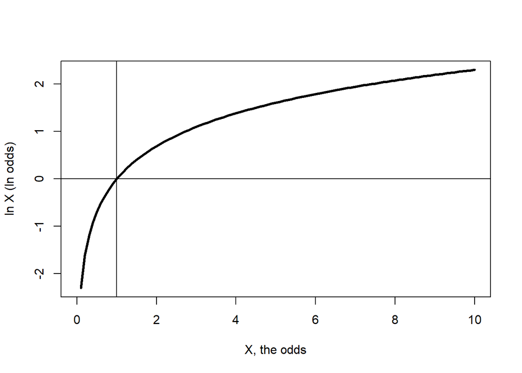

```r
x = seq(0,10, by = 0.1)
plot(x, log(x), xlab = 'X, the odds', ylab = 'ln X (ln odds)', type = 'n')
lines(x, log(x), lwd = 3)
abline(h = 0)
abline(v = 1)
```

Note that the natural log is zero when X is 1.

When X is larger than one, the log curves up slowly.

When X is less than one, the natural log is less than zero, and decreases rapidly as X approaches zero.

When P = 0.50, the odds are .50/.50 or 1, and ln(1) = 0.

If P is greater than .50, ln(P/(1-P) is positive; if P is less than .50, ln(odds) is negative.

A number taken to a negative power is one divided by that number, e.g. e-10 = 1/e10.

A logarithm is an exponent from a given base, for example ln(e10) = 10.

Indicates the change in odds resulting from a unit change in the predictor.

## 6.6 Back to logistic regression

In logistic regression, the dependent variable is a logit, which is the natural log of the odds, that is:

$log(odds) = logit(P)$

$log(odds) = ln(\frac{P}{1-P})$

So a logit is a log of odds and odds are a function of P, the probability of a 1. In logistic regression, we find:

$logit(P) = b_0 + b_1X$

$ln(\frac{P}{1-P}) = b_0 + b_1X$

$\frac{P}{1-P} = e^{b_0 + b_1X}$

## 6.7 Full worked example:

Suppose that we are working with some doctors on heart attack patients. The dependent variable is whether the patient has had a second heart attack within 1 year (yes = 1). We have two independent variables, one is whether the patient completed a treatment consistent of anger control practices (yes=1). The other IV is a score on a trait anxiety scale (a higher score means more anxious).

```
##    Person 2nd Heart Attack Treatment of Anger Trait Anxiety
## 1       1                1                  1            70
## 2       2                1                  1            80
## 3       3                1                  1            50
## 4       4                1                  0            60
## 5       5                1                  0            40
## 6       6                1                  0            65
## 7       7                1                  0            75
## 8       8                1                  0            80
## 9       9                1                  0            70
## 10     10                1                  0            60
## 11     11                0                  1            65
## 12     12                0                  1            50
## 13     13                0                  1            45
## 14     14                0                  1            35
## 15     15                0                  1            40
## 16     16                0                  1            50
## 17     17                0                  0            55
## 18     18                0                  0            45
## 19     19                0                  0            50
## 20     20                0                  0            60
```

Now let’s look at the logistic regression, for the moment examining the treatment of anger by itself, ignoring the anxiety test scores.

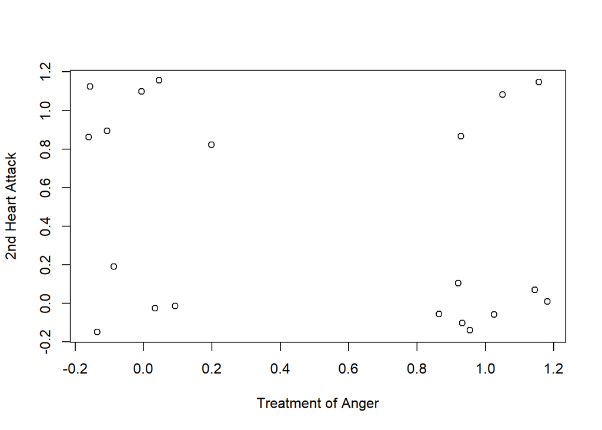

```
##
## Call:  glm(formula = data.$`2nd Heart Attack` ~ data.$`Treatment of Anger`,
##     family = binomial)
##
## Coefficients:
##                (Intercept)  data.$`Treatment of Anger`
##                     0.5596                     -1.2528
##
## Degrees of Freedom: 19 Total (i.e. Null);  18 Residual
## Null Deviance:       27.73
## Residual Deviance: 25.88     AIC: 29.88
```

As usual, we are not terribly interested in whether a is equal to zero.

The value of $b_1$ given for Anger Treatment is -1.2528.

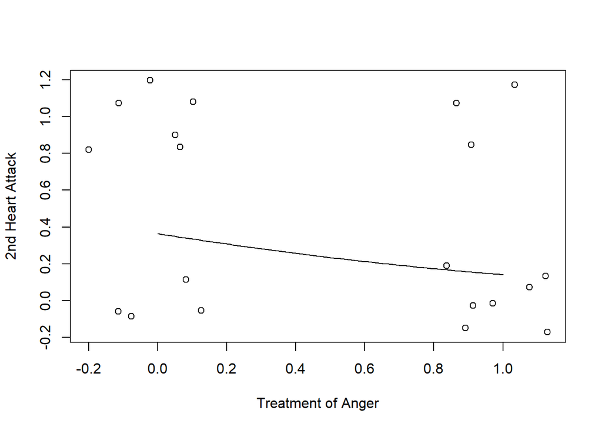

## 6.8 Let’s look at the odds ratio:

$odds = (\frac{P}{1-P})$

| Heart Attack | yes | no | total |  |
| --- | --- | --- | --- | --- |
| yes | 3 | 7 | 10 |  |
| no | 6 | 4 | 10 |  |
| total | 9 | 11 | 20 |  |

Now we can compute the odds of having a heart attack for the treatment group and the no treatment group.

For the treatment group, the odds are 3/6 = 1/2.

The probability of a heart attack is 3/(3+6) = 3/9 = 0.33.

The odds from this probability are 0.33/(1-.33) = 0.33/0.66 = 1/2.

The odds for the no treatment group are 7/4 or 1.75.

The odds ratio is calculated to compare the odds across groups.

[figure not shown]